# Data Wrangling with R’s tidyverse

dplyr, tidyr and friends

Author

Wilfried Cools & Lara Stas

Published

December 7, 2025

SQUARE consultants

square.research.vub.be

Compiled on R 4.5.2

**ImportantWhat-Why-Who**

This page aims to introduce researchers to data manipulation in R with the `dplyr`, `tidyr`, and `stringr` packages of the `tidyverse` ecosystem.

Our target audience is primarily the research community at VUB / UZ Brussel, those who have some basic experience in R and want to know more.

We invite you to help improve this document by sending us feedback: square@vub.be

**TipKey Message**

- Data manipulation is inherent to data analysis, not just a precursor
  - no -fit’s all data representation-
    - note: raw data should not be altered and kept safe
  - flexible use of data manipulation
    - supports more informative and complete modeling
    - elicits better visualization of data and statistics
- Workflow (Hadley Wickham):

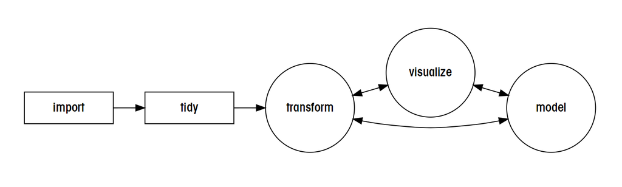

- Data manipulation is easier and more intuitive on tidy data.
  - ensure tidy data to start from
  - maintain tidy data

## R’s tidyverse packages: dplyr and tidyr

- Current defaults manipulating (dplyr) and tidying (tidyr) data
- Inspired heavily on relational database logic
- Largely consistent
- Well appreciated defaults
- Easy and intuitive to build (if you get it)
- Without loosing much flexibility
- Cheat sheets at [Posit](https://posit.co/resources/cheatsheets/)
- Alternative to base R, and other packages

## Getting ahead of ourselves with dplyr

#### toy dataset

- The infamous `mtcars` data are used.
  - observe it’s structure with `str( )` and first 6 observations `head( )` function.
  - note: available data with `data( )`
- Have a `tidyverse` look at the data with `glimpse( )`

```r
glimpse(mtcars)
```

```
Rows: 32
Columns: 11
$ mpg  <dbl> 21.0, 21.0, 22.8, 21.4, 18.7, 18.1, 14.3, 24.4, 22.8, 19.2, 17.8,…
$ cyl  <dbl> 6, 6, 4, 6, 8, 6, 8, 4, 4, 6, 6, 8, 8, 8, 8, 8, 8, 4, 4, 4, 4, 8,…
$ disp <dbl> 160.0, 160.0, 108.0, 258.0, 360.0, 225.0, 360.0, 146.7, 140.8, 16…
$ hp   <dbl> 110, 110, 93, 110, 175, 105, 245, 62, 95, 123, 123, 180, 180, 180…
$ drat <dbl> 3.90, 3.90, 3.85, 3.08, 3.15, 2.76, 3.21, 3.69, 3.92, 3.92, 3.92,…
$ wt   <dbl> 2.620, 2.875, 2.320, 3.215, 3.440, 3.460, 3.570, 3.190, 3.150, 3.…
$ qsec <dbl> 16.46, 17.02, 18.61, 19.44, 17.02, 20.22, 15.84, 20.00, 22.90, 18…
$ vs   <dbl> 0, 0, 1, 1, 0, 1, 0, 1, 1, 1, 1, 0, 0, 0, 0, 0, 0, 1, 1, 1, 1, 0,…
$ am   <dbl> 1, 1, 1, 0, 0, 0, 0, 0, 0, 0, 0, 0, 0, 0, 0, 0, 0, 1, 1, 1, 0, 0,…
$ gear <dbl> 4, 4, 4, 3, 3, 3, 3, 4, 4, 4, 4, 3, 3, 3, 3, 3, 3, 4, 4, 4, 3, 3,…
$ carb <dbl> 4, 4, 1, 1, 2, 1, 4, 2, 2, 4, 4, 3, 3, 3, 4, 4, 4, 1, 2, 1, 1, 2,…
```

- Have a `tidyverse` look at the data with `slice_head( )`

```r
mtcars |> slice_head(n=6)
```

```
                   mpg cyl disp  hp drat    wt  qsec vs am gear carb
Mazda RX4         21.0   6  160 110 3.90 2.620 16.46  0  1    4    4
Mazda RX4 Wag     21.0   6  160 110 3.90 2.875 17.02  0  1    4    4
Datsun 710        22.8   4  108  93 3.85 2.320 18.61  1  1    4    1
Hornet 4 Drive    21.4   6  258 110 3.08 3.215 19.44  1  0    3    1
Hornet Sportabout 18.7   8  360 175 3.15 3.440 17.02  0  0    3    2
Valiant           18.1   6  225 105 2.76 3.460 20.22  1  0    3    1
```

#### examplary data manipulation

- Get the minimum value of the ratio of `mpg` over `hp` where `hp` bigger than 3.5, for each combination of `am` and `cyl`.
  - take the `mtcars` data,
  - select variables `mpg`, `cyl`, `hp`, `am`, and rename `hp` to `hpow`,
  - subset rows where `hpow` bigger than 3.5,
  - create new variable `mpgr` as the ratio `mpg` on `hpow`,
  - for every combination of `cyl` and `am`, summarize `mpgr` as the minimum,
  - and reshape the result into a table with one row per `cyl`-value (4,6,8) and a column for each `am` value (0,1),
  - with column variable names renamed to `am0` and `am1`.
- Step by step, left to right

```r
mtcars |>
    select(mpg, cyl, hpow=hp, am) |>
    filter(hpow > 3.5) |>
    mutate(mpgr = mpg/hpow) |>
    group_by(cyl, am) |>
    summarize(min=min(mpgr)) |>
    pivot_wider(names_from=am,
        values_from=min) |>
    select(cyl,am0=`0`,am1=`1`)
```

| cyl | am0 | am1 |
| --- | --- | --- |
| 4 | 0.22164948 | 0.19633028 |
| 6 | 0.14471545 | 0.11257143 |
| 8 | 0.04837209 | 0.04477612 |

## `dplyr` package, functions to manipulate data

- `dplyr` reflects the `apply` function in base R
  - `d` is for data frames
- Focus on manipulating data frames (tibbles):
  - subsetting, altering, summarizing, ordering, combining, reshaping
- The main -verbs- (see example above)
  - `filter( )` : conditional selection of cases
  - `select( )` : conditional selection of variables, allows reordering and renaming
  - `mutate( )` : creation of new variables, possibly based on existing variables
  - `summarize( )` : reduce sets of values to single values
- The verb to structure data (see example above)
  - `group_by( )` : internal grouping, undo with ungroup( )
  - grouped structure used by `summarize()`, `mutate()`, …
- The verbs to enhance control on scope (advanced)
  - `across( )` : for set of variables
    - works for selection in `mutate( ) and summarize( )`
- Additional `dplyr` verbs:
  - `arrange` : ordering of cases
  - `sample_n` and `sample_frac` : random sampling
  - `slice`, `transmute`, `rename`, `relocate`, …
- Verbs to extend data
  - `bind_rows` and `bind_cols` : append data of same structure
  - `left_join`, `right_join`, `inner_join`, `full_join`, `semi_join` and `anti_join` : join data using indicator variable(s)

### group_by( )

- Grouping prepares data for group specific operations
  - functions will recognize the grouping within the data
  - adjust grouping appropriately

#### intro

- Get a glimpse of the data as before,
  - number of rows and columns
    - in tidy data: observations and variables
  - number of groups, and grouping variables
    - 4 groups: 2 am x 2 vs
    - Note: grouping structure part of `glimpse`-output
  - width set for presentation purposes only

```r
tst <- mtcars |> group_by(am,vs)
glimpse(tst,width=40)
```

```
Rows: 32
Columns: 11
Groups: am, vs [4]
$ mpg  <dbl> 21.0, 21.0, 22.8, 21.4, 1…
$ cyl  <dbl> 6, 6, 4, 6, 8, 6, 8, 4, 4…
$ disp <dbl> 160.0, 160.0, 108.0, 258.…
$ hp   <dbl> 110, 110, 93, 110, 175, 1…
$ drat <dbl> 3.90, 3.90, 3.85, 3.08, 3…
$ wt   <dbl> 2.620, 2.875, 2.320, 3.21…
$ qsec <dbl> 16.46, 17.02, 18.61, 19.4…
$ vs   <dbl> 0, 0, 1, 1, 0, 1, 0, 1, 1…
$ am   <dbl> 1, 1, 1, 0, 0, 0, 0, 0, 0…
$ gear <dbl> 4, 4, 4, 3, 3, 3, 3, 4, 4…
$ carb <dbl> 4, 4, 1, 1, 2, 1, 4, 2, 2…
```

- Actions on grouped data are grouped too,
  - e.g., a frequency table, count the number of observations (`count( )`)
  - grouped data result in grouped counts

```r
tst |> count()
```

| am | vs | n |
| --- | --- | --- |
| 0 | 0 | 12 |
| 0 | 1 | 7 |
| 1 | 0 | 6 |
| 1 | 1 | 7 |

- Remove grouping with `ungroup( )`
  - this is good practice to avoid unwanted effects !

```r
tst <- tst |> ungroup( )
tst |> count()
```

| n |
| --- |
| 32 |

- Alternatively, overwrite the initial grouping
  - the last grouping is used by default
  - additional arguments, for example .add and .drop, can change that
    - a first groups by `vs`
    - a second groups by `am` and `vs`

```r
mtcars |> group_by(am) |> group_by(vs)
mtcars |> group_by(am) |> group_by(vs, .add=TRUE)
```

- Transformed variables can also be used for grouping
  - e.g., cutting the `mpg` in 3 groups with `cut_interval( )` then use `count( )`  
    Notice the intervals that are created.

```r
tst <- mtcars |>
    group_by(mpg3 = cut_interval(mpg, 3))
tst |> count()
```

| mpg3 | n |
| --- | --- |
| [10.4,18.2] | 14 |
| (18.2,26.1] | 13 |
| (26.1,33.9] | 5 |

#### exercises

- Embedded within the next sections

### filter( )

- Filtering returns rows using matching conditions
- Other functions exist to select rows

#### intro

- Get a subset of rows that includes only those rows with `mpg` above 30

```r
mtcars |> filter(mpg > 30)
```

| mpg | cyl | disp | hp | drat | wt | qsec | vs | am | gear | carb |
| --- | --- | --- | --- | --- | --- | --- | --- | --- | --- | --- |
| 32.4 | 4 | 78.7 | 66 | 4.08 | 2.200 | 19.47 | 1 | 1 | 4 | 1 |
| 30.4 | 4 | 75.7 | 52 | 4.93 | 1.615 | 18.52 | 1 | 1 | 4 | 2 |
| 33.9 | 4 | 71.1 | 65 | 4.22 | 1.835 | 19.90 | 1 | 1 | 4 | 1 |
| 30.4 | 4 | 95.1 | 113 | 3.77 | 1.513 | 16.90 | 1 | 1 | 5 | 2 |

- Include more than just one condition,
  - take only rows with `mpg` above 20 AND `qsec` below or equal to 18
  - note: consecutive filtering achieves the same.
    - `&` for `and`
    - `|` for `or`
    - `!` for `not`

```r
mtcars |> filter(mpg > 20 & qsec <= 18)
```

| mpg | cyl | disp | hp | drat | wt | qsec | vs | am | gear | carb |
| --- | --- | --- | --- | --- | --- | --- | --- | --- | --- | --- |
| 21.0 | 6 | 160.0 | 110 | 3.90 | 2.620 | 16.46 | 0 | 1 | 4 | 4 |
| 21.0 | 6 | 160.0 | 110 | 3.90 | 2.875 | 17.02 | 0 | 1 | 4 | 4 |
| 26.0 | 4 | 120.3 | 91 | 4.43 | 2.140 | 16.70 | 0 | 1 | 5 | 2 |
| 30.4 | 4 | 95.1 | 113 | 3.77 | 1.513 | 16.90 | 1 | 1 | 5 | 2 |

```r
mtcars |> filter(mpg > 30 | (qsec > 20 & am==0))
```

| mpg | cyl | disp | hp | drat | wt | qsec | vs | am | gear | carb |
| --- | --- | --- | --- | --- | --- | --- | --- | --- | --- | --- |
| 18.1 | 6 | 225.0 | 105 | 2.76 | 3.460 | 20.22 | 1 | 0 | 3 | 1 |
| 22.8 | 4 | 140.8 | 95 | 3.92 | 3.150 | 22.90 | 1 | 0 | 4 | 2 |
| 32.4 | 4 | 78.7 | 66 | 4.08 | 2.200 | 19.47 | 1 | 1 | 4 | 1 |
| 30.4 | 4 | 75.7 | 52 | 4.93 | 1.615 | 18.52 | 1 | 1 | 4 | 2 |
| 33.9 | 4 | 71.1 | 65 | 4.22 | 1.835 | 19.90 | 1 | 1 | 4 | 1 |
| 21.5 | 4 | 120.1 | 97 | 3.70 | 2.465 | 20.01 | 1 | 0 | 3 | 1 |
| 30.4 | 4 | 95.1 | 113 | 3.77 | 1.513 | 16.90 | 1 | 1 | 5 | 2 |

- Grouping also works here
  - get all `distinct` values of `cyl` per level of `gear`
  - note: this selects the first unique rows

```r
mtcars |> group_by(gear) |> distinct(cyl)
```

| gear | cyl |
| --- | --- |
| 4 | 6 |
| 4 | 4 |
| 3 | 6 |
| 3 | 8 |
| 3 | 4 |
| 5 | 4 |
| 5 | 8 |
| 5 | 6 |

#### exercises

- The `starwars` dataset is already part of tidyverse, so you should have it available !
- Have a glimpse at the data, what data types are included ?

**a tidyverse solution**

```r
glimpse(starwars)
```

```
Rows: 87
Columns: 14
$ name       <chr> "Luke Skywalker", "C-3PO", "R2-D2", "Darth Vader", "Leia Or…
$ height     <int> 172, 167, 96, 202, 150, 178, 165, 97, 183, 182, 188, 180, 2…
$ mass       <dbl> 77.0, 75.0, 32.0, 136.0, 49.0, 120.0, 75.0, 32.0, 84.0, 77.…
$ hair_color <chr> "blond", NA, NA, "none", "brown", "brown, grey", "brown", N…
$ skin_color <chr> "fair", "gold", "white, blue", "white", "light", "light", "…
$ eye_color  <chr> "blue", "yellow", "red", "yellow", "brown", "blue", "blue",…
$ birth_year <dbl> 19.0, 112.0, 33.0, 41.9, 19.0, 52.0, 47.0, NA, 24.0, 57.0, …
$ sex        <chr> "male", "none", "none", "male", "female", "male", "female",…
$ gender     <chr> "masculine", "masculine", "masculine", "masculine", "femini…
$ homeworld  <chr> "Tatooine", "Tatooine", "Naboo", "Tatooine", "Alderaan", "T…
$ species    <chr> "Human", "Droid", "Droid", "Human", "Human", "Human", "Huma…
$ films      <list> <"A New Hope", "The Empire Strikes Back", "Return of the J…
$ vehicles   <list> <"Snowspeeder", "Imperial Speeder Bike">, <>, <>, <>, "Imp…
$ starships  <list> <"X-wing", "Imperial shuttle">, <>, <>, "TIE Advanced x1",…
```

- Do note, different data types are included in the tibble (data frame)
  - `chr` for characters, `int` for integers, `dbl` for doubles, we miss the `lgl` for a boolean
  - notice that even a vector of type `list` can be included.
- filter() the rows to subset the data and retain only movie characters with light skin and brown eye color

**a tidyverse solution**

```r
starwars |> filter(skin_color == "light" & eye_color == "brown")
```

```
# A tibble: 7 × 14
  name      height  mass hair_color skin_color eye_color birth_year sex   gender
  <chr>      <int> <dbl> <chr>      <chr>      <chr>          <dbl> <chr> <chr>
1 Leia Org…    150    49 brown      light      brown             19 fema… femin…
2 Biggs Da…    183    84 black      light      brown             24 male  mascu…
3 Padmé Am…    185    45 brown      light      brown             46 fema… femin…
4 Cordé        157    NA brown      light      brown             NA <NA>  <NA>
5 Dormé        165    NA brown      light      brown             NA fema… femin…
6 Raymus A…    188    79 brown      light      brown             NA male  mascu…
7 Poe Dame…     NA    NA brown      light      brown             NA male  mascu…
# ℹ 5 more variables: homeworld <chr>, species <chr>, films <list>,
#   vehicles <list>, starships <list>
```

- arrange() the data according the character’s height, who is the smallest ?

**a tidyverse solution**

```r
starwars |> arrange(height)
```

```
# A tibble: 87 × 14
   name     height  mass hair_color skin_color eye_color birth_year sex   gender
   <chr>     <int> <dbl> <chr>      <chr>      <chr>          <dbl> <chr> <chr>
 1 Yoda         66    17 white      green      brown            896 male  mascu…
 2 Ratts T…     79    15 none       grey, blue unknown           NA male  mascu…
 3 Wicket …     88    20 brown      brown      brown              8 male  mascu…
 4 Dud Bolt     94    45 none       blue, grey yellow            NA male  mascu…
 5 R2-D2        96    32 <NA>       white, bl… red               33 none  mascu…
 6 R4-P17       96    NA none       silver, r… red, blue         NA none  femin…
 7 R5-D4        97    32 <NA>       white, red red               NA none  mascu…
 8 Sebulba     112    40 none       grey, red  orange            NA male  mascu…
 9 Gasgano     122    NA none       white, bl… black             NA male  mascu…
10 Watto       137    NA black      blue, grey yellow            NA male  mascu…
# ℹ 77 more rows
# ℹ 5 more variables: homeworld <chr>, species <chr>, films <list>,
#   vehicles <list>, starships <list>
```

- re-arrange, largest on top [hint: desc()], who is the largest ?

**a tidyverse solution**

```r
starwars |> arrange(desc(height))
```

```
# A tibble: 87 × 14
   name     height  mass hair_color skin_color eye_color birth_year sex   gender
   <chr>     <int> <dbl> <chr>      <chr>      <chr>          <dbl> <chr> <chr>
 1 Yarael …    264    NA none       white      yellow          NA   male  mascu…
 2 Tarfful     234   136 brown      brown      blue            NA   male  mascu…
 3 Lama Su     229    88 none       grey       black           NA   male  mascu…
 4 Chewbac…    228   112 brown      unknown    blue           200   male  mascu…
 5 Roos Ta…    224    82 none       grey       orange          NA   male  mascu…
 6 Grievous    216   159 none       brown, wh… green, y…       NA   male  mascu…
 7 Taun We     213    NA none       grey       black           NA   fema… femin…
 8 Rugor N…    206    NA none       green      orange          NA   male  mascu…
 9 Tion Me…    206    80 none       grey       black           NA   male  mascu…
10 Darth V…    202   136 none       white      yellow          41.9 male  mascu…
# ℹ 77 more rows
# ℹ 5 more variables: homeworld <chr>, species <chr>, films <list>,
#   vehicles <list>, starships <list>
```

- slice() the data and keep only the 5th to 10th observation ! (`?slice`)

**a tidyverse solution**

```r
starwars |> slice(5:10)
```

```
# A tibble: 6 × 14
  name      height  mass hair_color skin_color eye_color birth_year sex   gender
  <chr>      <int> <dbl> <chr>      <chr>      <chr>          <dbl> <chr> <chr>
1 Leia Org…    150    49 brown      light      brown             19 fema… femin…
2 Owen Lars    178   120 brown, gr… light      blue              52 male  mascu…
3 Beru Whi…    165    75 brown      light      blue              47 fema… femin…
4 R5-D4         97    32 <NA>       white, red red               NA none  mascu…
5 Biggs Da…    183    84 black      light      brown             24 male  mascu…
6 Obi-Wan …    182    77 auburn, w… fair       blue-gray         57 male  mascu…
# ℹ 5 more variables: homeworld <chr>, species <chr>, films <list>,
#   vehicles <list>, starships <list>
```

- slice the first 2 observations [hint: slice_head()] for each gender (group your data) !
  - what other functions are discussed at `?slice_head` ?

**a tidyverse solution**

```r
starwars |> group_by(gender) |> slice_head(n=2)
```

```
# A tibble: 6 × 14
# Groups:   gender [3]
  name      height  mass hair_color skin_color eye_color birth_year sex   gender
  <chr>      <int> <dbl> <chr>      <chr>      <chr>          <dbl> <chr> <chr>
1 Leia Org…    150    49 brown      light      brown             19 fema… femin…
2 Beru Whi…    165    75 brown      light      blue              47 fema… femin…
3 Luke Sky…    172    77 blond      fair       blue              19 male  mascu…
4 C-3PO        167    75 <NA>       gold       yellow           112 none  mascu…
5 Jek Tono…    180   110 brown      fair       blue              NA <NA>  <NA>
6 Gregar T…    185    85 black      dark       brown             NA <NA>  <NA>
# ℹ 5 more variables: homeworld <chr>, species <chr>, films <list>,
#   vehicles <list>, starships <list>
```

- slice 5 observations randomly [hint: slice_sample( )] !

**a tidyverse solution**

```r
starwars |> slice_sample(n = 5)
```

```
# A tibble: 5 × 14
  name      height  mass hair_color skin_color eye_color birth_year sex   gender
  <chr>      <int> <dbl> <chr>      <chr>      <chr>          <dbl> <chr> <chr>
1 Jabba De…    175  1358 <NA>       green-tan… orange           600 herm… mascu…
2 Gasgano      122    NA none       white, bl… black             NA male  mascu…
3 Obi-Wan …    182    77 auburn, w… fair       blue-gray         57 male  mascu…
4 Greedo       173    74 <NA>       green      black             44 male  mascu…
5 Bossk        190   113 none       green      red               53 male  mascu…
# ℹ 5 more variables: homeworld <chr>, species <chr>, films <list>,
#   vehicles <list>, starships <list>
```

- slice the 3 highest values for `height` [hint: slice_max( )] !

**a tidyverse solution**

```r
starwars |> slice_max(height, n = 3)
```

```
# A tibble: 3 × 14
  name      height  mass hair_color skin_color eye_color birth_year sex   gender
  <chr>      <int> <dbl> <chr>      <chr>      <chr>          <dbl> <chr> <chr>
1 Yarael P…    264    NA none       white      yellow            NA male  mascu…
2 Tarfful      234   136 brown      brown      blue              NA male  mascu…
3 Lama Su      229    88 none       grey       black             NA male  mascu…
# ℹ 5 more variables: homeworld <chr>, species <chr>, films <list>,
#   vehicles <list>, starships <list>
```

- slice the 3 highest values for `mass` for each species that defined (not missing) !
  - note, -not missing- are those who are not `!` missing `is.na()`

**a tidyverse solution**

```r
starwars |> group_by(species) |> filter(!is.na(mass)) |> slice_max(mass, n = 3)
```

```
# A tibble: 42 × 14
# Groups:   species [32]
   name     height  mass hair_color skin_color eye_color birth_year sex   gender
   <chr>     <int> <dbl> <chr>      <chr>      <chr>          <dbl> <chr> <chr>
 1 Ratts T…     79    15 none       grey, blue unknown           NA male  mascu…
 2 Dexter …    198   102 none       brown      yellow            NA male  mascu…
 3 Ki-Adi-…    198    82 white      pale       yellow            92 male  mascu…
 4 Zam Wes…    168    55 blonde     fair, gre… yellow            NA fema… femin…
 5 IG-88       200   140 none       metal      red               15 none  mascu…
 6 C-3PO       167    75 <NA>       gold       yellow           112 none  mascu…
 7 R2-D2        96    32 <NA>       white, bl… red               33 none  mascu…
 8 R5-D4        97    32 <NA>       white, red red               NA none  mascu…
 9 Sebulba     112    40 none       grey, red  orange            NA male  mascu…
10 Wicket …     88    20 brown      brown      brown              8 male  mascu…
# ℹ 32 more rows
# ℹ 5 more variables: homeworld <chr>, species <chr>, films <list>,
#   vehicles <list>, starships <list>
```

### select( )

- Selection returns columns (variables) by matching conditions, by name (or position)
- Selection can rename and/or reorder columns (variables)

#### intro

- select() the variable `mpg`
  - notice that even with one column, the result remains a dataframe (not a vector)
- `tidyverse policy`: an operation on a data with a certain type should result in data of the same type.
  - if you take one column from a matrix, you have a one column matrix, not a vector.
  - if you take one column from a data frame, you have a one-column data frame, not a vector.

```r
mtcars |> select(mpg)
```

| mpg |
| --- |
| 21.0 |
| 21.0 |
| 22.8 |
| 21.4 |
| 18.7 |
| 18.1 |

- Dedicated functions allow for changing data types
- pull() a column out of a dataframe into a vector

```r
mtcars |> pull(mpg)
```

```
 [1] 21.0 21.0 22.8 21.4 18.7 18.1 14.3 24.4 22.8 19.2 17.8 16.4 17.3 15.2 10.4
[16] 10.4 14.7 32.4 30.4 33.9 21.5 15.5 15.2 13.3 19.2 27.3 26.0 30.4 15.8 19.7
[31] 15.0 21.4
```

- select() columns `qsec` and `mpg`
  - note: multiple columns can be listed, this is not a condition
  - note: only the top 6 are presented

```r
mtcars |> select(qsec,mpg)
```

| qsec | mpg |
| --- | --- |
| 16.46 | 21.0 |
| 17.02 | 21.0 |
| 18.61 | 22.8 |
| 19.44 | 21.4 |
| 17.02 | 18.7 |
| 20.22 | 18.1 |

- select() the third and first column in that order
  - note: columns can be extracted by their position

```r
mtcars |> select(3,1)
```

| disp | mpg |
| --- | --- |
| 160 | 21.0 |
| 160 | 21.0 |
| 108 | 22.8 |
| 258 | 21.4 |
| 360 | 18.7 |
| 225 | 18.1 |

- select() away columns at third to sixth position
  - note: to remove, use a negation
  - note: select can either keep or remove columns, not both

```r
mtcars |> select(-c(3:6))
```

| mpg | cyl | qsec | vs | am | gear | carb |
| --- | --- | --- | --- | --- | --- | --- |
| 21.0 | 6 | 16.46 | 0 | 1 | 4 | 4 |
| 21.0 | 6 | 17.02 | 0 | 1 | 4 | 4 |
| 22.8 | 4 | 18.61 | 1 | 1 | 4 | 1 |
| 21.4 | 6 | 19.44 | 1 | 0 | 3 | 1 |
| 18.7 | 8 | 17.02 | 0 | 0 | 3 | 2 |
| 18.1 | 6 | 20.22 | 1 | 0 | 3 | 1 |

- select() variables mpg, cyl, vs and am, while renaming cyl as cyl468, vs as vs01, and am as am01

```r
mtcars |> select(mpg,cyl468=cyl,vs01=vs,am01=am)
```

| mpg | cyl468 | vs01 | am01 |
| --- | --- | --- | --- |
| 21.0 | 6 | 0 | 1 |
| 21.0 | 6 | 0 | 1 |
| 22.8 | 4 | 1 | 1 |
| 21.4 | 6 | 1 | 0 |
| 18.7 | 8 | 0 | 0 |
| 18.1 | 6 | 1 | 0 |

```r
mtcars |> rename(cyl468=cyl,vs01=vs,am01=am)
```

| mpg | cyl468 | disp | hp | drat | wt | qsec | vs01 | am01 | gear | carb |
| --- | --- | --- | --- | --- | --- | --- | --- | --- | --- | --- |
| 21.0 | 6 | 160 | 110 | 3.90 | 2.620 | 16.46 | 0 | 1 | 4 | 4 |
| 21.0 | 6 | 160 | 110 | 3.90 | 2.875 | 17.02 | 0 | 1 | 4 | 4 |
| 22.8 | 4 | 108 | 93 | 3.85 | 2.320 | 18.61 | 1 | 1 | 4 | 1 |
| 21.4 | 6 | 258 | 110 | 3.08 | 3.215 | 19.44 | 1 | 0 | 3 | 1 |
| 18.7 | 8 | 360 | 175 | 3.15 | 3.440 | 17.02 | 0 | 0 | 3 | 2 |
| 18.1 | 6 | 225 | 105 | 2.76 | 3.460 | 20.22 | 1 | 0 | 3 | 1 |

- group_by() `am` and `vs`, then select only `mpg`
  - note: grouping variables are always included

```r
mtcars |> group_by(vs,am) |> select(mpg)
```

[output not shown]

- **helper functions** can facilitate selections
- select() columns with names that `contains()` the string `ar`

```r
mtcars |> select(contains('ar'))
```

| gear | carb |
| --- | --- |
| 4 | 4 |
| 4 | 4 |
| 4 | 1 |
| 3 | 1 |
| 3 | 2 |
| 3 | 1 |

- Use regular expressions with `matches( )`
- select() columns with names that include at least one element before `ar` and at least one after it by, so that it `matches()` the regular expression `.ar.`

```r
mtcars |> select(matches('.ar.'))
```

| carb |
| --- |
| 4 |
| 4 |
| 1 |
| 1 |
| 2 |
| 1 |

#### exercises

- The `starwars` dataset is probably still loaded into your workspace !
- Select the columns hair, skin and eye color !

**a tidyverse solution**

```r
starwars |> select(hair_color, skin_color, eye_color)
```

```
# A tibble: 87 × 3
   hair_color    skin_color  eye_color
   <chr>         <chr>       <chr>
 1 blond         fair        blue
 2 <NA>          gold        yellow
 3 <NA>          white, blue red
 4 none          white       yellow
 5 brown         light       brown
 6 brown, grey   light       blue
 7 brown         light       blue
 8 <NA>          white, red  red
 9 black         light       brown
10 auburn, white fair        blue-gray
# ℹ 77 more rows
```

- Use the `:` operator for consecutive columns between hair and eye color !

**a tidyverse solution**

```r
starwars |> select(hair_color:eye_color)
```

```
# A tibble: 87 × 3
   hair_color    skin_color  eye_color
   <chr>         <chr>       <chr>
 1 blond         fair        blue
 2 <NA>          gold        yellow
 3 <NA>          white, blue red
 4 none          white       yellow
 5 brown         light       brown
 6 brown, grey   light       blue
 7 brown         light       blue
 8 <NA>          white, red  red
 9 black         light       brown
10 auburn, white fair        blue-gray
# ℹ 77 more rows
```

- Remove these columns instead of selecting them !

**a tidyverse solution**

```r
starwars |> select(-(hair_color:eye_color))
```

```
# A tibble: 87 × 11
   name    height  mass birth_year sex   gender homeworld species films vehicles
   <chr>    <int> <dbl>      <dbl> <chr> <chr>  <chr>     <chr>   <lis> <list>
 1 Luke S…    172    77       19   male  mascu… Tatooine  Human   <chr> <chr>
 2 C-3PO      167    75      112   none  mascu… Tatooine  Droid   <chr> <chr>
 3 R2-D2       96    32       33   none  mascu… Naboo     Droid   <chr> <chr>
 4 Darth …    202   136       41.9 male  mascu… Tatooine  Human   <chr> <chr>
 5 Leia O…    150    49       19   fema… femin… Alderaan  Human   <chr> <chr>
 6 Owen L…    178   120       52   male  mascu… Tatooine  Human   <chr> <chr>
 7 Beru W…    165    75       47   fema… femin… Tatooine  Human   <chr> <chr>
 8 R5-D4       97    32       NA   none  mascu… Tatooine  Droid   <chr> <chr>
 9 Biggs …    183    84       24   male  mascu… Tatooine  Human   <chr> <chr>
10 Obi-Wa…    182    77       57   male  mascu… Stewjon   Human   <chr> <chr>
# ℹ 77 more rows
# ℹ 1 more variable: starships <list>
```

- Select all columns with a name ending with `color` [hint: ends_with()] !

**a tidyverse solution**

```r
starwars |> select(ends_with("color"))
```

```
# A tibble: 87 × 3
   hair_color    skin_color  eye_color
   <chr>         <chr>       <chr>
 1 blond         fair        blue
 2 <NA>          gold        yellow
 3 <NA>          white, blue red
 4 none          white       yellow
 5 brown         light       brown
 6 brown, grey   light       blue
 7 brown         light       blue
 8 <NA>          white, red  red
 9 black         light       brown
10 auburn, white fair        blue-gray
# ℹ 77 more rows
```

- Use select to rename `homeworld` to `home_world` !

**a tidyverse solution**

```r
starwars |> select(home_world = homeworld)
```

```
# A tibble: 87 × 1
   home_world
   <chr>
 1 Tatooine
 2 Tatooine
 3 Naboo
 4 Tatooine
 5 Alderaan
 6 Tatooine
 7 Tatooine
 8 Tatooine
 9 Tatooine
10 Stewjon
# ℹ 77 more rows
```

- Do the same with the `rename( )` function !

**a tidyverse solution**

```r
starwars |> rename(home_world = homeworld)
```

```
# A tibble: 87 × 14
   name     height  mass hair_color skin_color eye_color birth_year sex   gender
   <chr>     <int> <dbl> <chr>      <chr>      <chr>          <dbl> <chr> <chr>
 1 Luke Sk…    172    77 blond      fair       blue            19   male  mascu…
 2 C-3PO       167    75 <NA>       gold       yellow         112   none  mascu…
 3 R2-D2        96    32 <NA>       white, bl… red             33   none  mascu…
 4 Darth V…    202   136 none       white      yellow          41.9 male  mascu…
 5 Leia Or…    150    49 brown      light      brown           19   fema… femin…
 6 Owen La…    178   120 brown, gr… light      blue            52   male  mascu…
 7 Beru Wh…    165    75 brown      light      blue            47   fema… femin…
 8 R5-D4        97    32 <NA>       white, red red             NA   none  mascu…
 9 Biggs D…    183    84 black      light      brown           24   male  mascu…
10 Obi-Wan…    182    77 auburn, w… fair       blue-gray       57   male  mascu…
# ℹ 77 more rows
# ℹ 5 more variables: home_world <chr>, species <chr>, films <list>,
#   vehicles <list>, starships <list>
```

- Select only the numeric variables using the `where( )` function with the `is.numeric` condition !

**a tidyverse solution**

```r
starwars |> select(where(is.numeric))
```

```
# A tibble: 87 × 3
   height  mass birth_year
    <int> <dbl>      <dbl>
 1    172    77       19
 2    167    75      112
 3     96    32       33
 4    202   136       41.9
 5    150    49       19
 6    178   120       52
 7    165    75       47
 8     97    32       NA
 9    183    84       24
10    182    77       57
# ℹ 77 more rows
```

- Select only those variables with names `height`, `mass` and/or `size`, with `any_of( )` !

**a tidyverse solution**

```r
starwars |> select(any_of(c('height','mass','size')))
```

```
# A tibble: 87 × 2
   height  mass
    <int> <dbl>
 1    172    77
 2    167    75
 3     96    32
 4    202   136
 5    150    49
 6    178   120
 7    165    75
 8     97    32
 9    183    84
10    182    77
# ℹ 77 more rows
```

- Select only those variables related to color (variables have names that end with ‘color’), and include the name.

**a tidyverse solution**

```r
starwars |> select(name,ends_with('color'))
```

```
# A tibble: 87 × 4
   name               hair_color    skin_color  eye_color
   <chr>              <chr>         <chr>       <chr>
 1 Luke Skywalker     blond         fair        blue
 2 C-3PO              <NA>          gold        yellow
 3 R2-D2              <NA>          white, blue red
 4 Darth Vader        none          white       yellow
 5 Leia Organa        brown         light       brown
 6 Owen Lars          brown, grey   light       blue
 7 Beru Whitesun Lars brown         light       blue
 8 R5-D4              <NA>          white, red  red
 9 Biggs Darklighter  black         light       brown
10 Obi-Wan Kenobi     auburn, white fair        blue-gray
# ℹ 77 more rows
```

### mutate( )

- Create new variables based on existing ones

#### intro

- A new variable (column) `mpg2` can be created by `mpg` value squared

```r
mtcars |> mutate(mpg2=mpg^2)
```

| mpg | cyl | disp | hp | drat | wt | qsec | vs | am | gear | carb | mpg2 |
| --- | --- | --- | --- | --- | --- | --- | --- | --- | --- | --- | --- |
| 21.0 | 6 | 160 | 110 | 3.90 | 2.620 | 16.46 | 0 | 1 | 4 | 4 | 441.00 |
| 21.0 | 6 | 160 | 110 | 3.90 | 2.875 | 17.02 | 0 | 1 | 4 | 4 | 441.00 |
| 22.8 | 4 | 108 | 93 | 3.85 | 2.320 | 18.61 | 1 | 1 | 4 | 1 | 519.84 |
| 21.4 | 6 | 258 | 110 | 3.08 | 3.215 | 19.44 | 1 | 0 | 3 | 1 | 457.96 |
| 18.7 | 8 | 360 | 175 | 3.15 | 3.440 | 17.02 | 0 | 0 | 3 | 2 | 349.69 |
| 18.1 | 6 | 225 | 105 | 2.76 | 3.460 | 20.22 | 1 | 0 | 3 | 1 | 327.61 |

- The original value can also be overwritten
  - e.g., the `mpg` can be assigned the values of `mpg` squared

```r
mtcars |> mutate(mpg=mpg^2)
```

| mpg | cyl | disp | hp | drat | wt | qsec | vs | am | gear | carb |
| --- | --- | --- | --- | --- | --- | --- | --- | --- | --- | --- |
| 441.00 | 6 | 160 | 110 | 3.90 | 2.620 | 16.46 | 0 | 1 | 4 | 4 |
| 441.00 | 6 | 160 | 110 | 3.90 | 2.875 | 17.02 | 0 | 1 | 4 | 4 |
| 519.84 | 4 | 108 | 93 | 3.85 | 2.320 | 18.61 | 1 | 1 | 4 | 1 |
| 457.96 | 6 | 258 | 110 | 3.08 | 3.215 | 19.44 | 1 | 0 | 3 | 1 |
| 349.69 | 8 | 360 | 175 | 3.15 | 3.440 | 17.02 | 0 | 0 | 3 | 2 |
| 327.61 | 6 | 225 | 105 | 2.76 | 3.460 | 20.22 | 1 | 0 | 3 | 1 |

- Based on multiple variables, e.g., `NEWVAR` can represent the `mpg` value multiplied by the `vs` value
- The convenient `everything` function is a short-cut to every column not explicitely mentioned

```r
mtcars |> mutate(NEWVAR=mpg*vs) |> select(NEWVAR,everything())
```

| NEWVAR | mpg | cyl | disp | hp | drat | wt | qsec | vs | am | gear | carb |
| --- | --- | --- | --- | --- | --- | --- | --- | --- | --- | --- | --- |
| 0.0 | 21.0 | 6 | 160 | 110 | 3.90 | 2.620 | 16.46 | 0 | 1 | 4 | 4 |
| 0.0 | 21.0 | 6 | 160 | 110 | 3.90 | 2.875 | 17.02 | 0 | 1 | 4 | 4 |
| 22.8 | 22.8 | 4 | 108 | 93 | 3.85 | 2.320 | 18.61 | 1 | 1 | 4 | 1 |
| 21.4 | 21.4 | 6 | 258 | 110 | 3.08 | 3.215 | 19.44 | 1 | 0 | 3 | 1 |
| 0.0 | 18.7 | 8 | 360 | 175 | 3.15 | 3.440 | 17.02 | 0 | 0 | 3 | 2 |
| 18.1 | 18.1 | 6 | 225 | 105 | 2.76 | 3.460 | 20.22 | 1 | 0 | 3 | 1 |

- A new variable can be created based on a newly created variable as well
  - e.g., `NEWVAR` is the `mpg` value multiplied by the `vs` value and this new variable is divided by the `disp` variable

```r
mtcars |> mutate(NEWVAR=mpg*vs,NEWVAR2=NEWVAR/disp) |> select(NEWVAR,NEWVAR2,everything())
```

| NEWVAR | NEWVAR2 | mpg | cyl | disp | hp | drat | wt | qsec | vs | am | gear | carb |
| --- | --- | --- | --- | --- | --- | --- | --- | --- | --- | --- | --- | --- |
| 0.0 | 0.00000000 | 21.0 | 6 | 160 | 110 | 3.90 | 2.620 | 16.46 | 0 | 1 | 4 | 4 |
| 0.0 | 0.00000000 | 21.0 | 6 | 160 | 110 | 3.90 | 2.875 | 17.02 | 0 | 1 | 4 | 4 |
| 22.8 | 0.21111111 | 22.8 | 4 | 108 | 93 | 3.85 | 2.320 | 18.61 | 1 | 1 | 4 | 1 |
| 21.4 | 0.08294574 | 21.4 | 6 | 258 | 110 | 3.08 | 3.215 | 19.44 | 1 | 0 | 3 | 1 |
| 0.0 | 0.00000000 | 18.7 | 8 | 360 | 175 | 3.15 | 3.440 | 17.02 | 0 | 0 | 3 | 2 |
| 18.1 | 0.08044444 | 18.1 | 6 | 225 | 105 | 2.76 | 3.460 | 20.22 | 1 | 0 | 3 | 1 |

- *window functions* facilitate the automation of mutations (google for dplyr window functions).
  - e.g., add a column with the cumulative sum of `mpg` using `cumsum( )`

```r
mtcars |> mutate(NEWVAR=cumsum(mpg))
```

| mpg | cyl | disp | hp | drat | wt | qsec | vs | am | gear | carb | NEWVAR |
| --- | --- | --- | --- | --- | --- | --- | --- | --- | --- | --- | --- |
| 21.0 | 6 | 160 | 110 | 3.90 | 2.620 | 16.46 | 0 | 1 | 4 | 4 | 21.0 |
| 21.0 | 6 | 160 | 110 | 3.90 | 2.875 | 17.02 | 0 | 1 | 4 | 4 | 42.0 |
| 22.8 | 4 | 108 | 93 | 3.85 | 2.320 | 18.61 | 1 | 1 | 4 | 1 | 64.8 |
| 21.4 | 6 | 258 | 110 | 3.08 | 3.215 | 19.44 | 1 | 0 | 3 | 1 | 86.2 |
| 18.7 | 8 | 360 | 175 | 3.15 | 3.440 | 17.02 | 0 | 0 | 3 | 2 | 104.9 |
| 18.1 | 6 | 225 | 105 | 2.76 | 3.460 | 20.22 | 1 | 0 | 3 | 1 | 123.0 |

- Add a column with indicator whether the `mpg` is between 20 and 22

```r
mtcars |> mutate(NEWVAR=between(mpg,20,22)) |> select(NEWVAR,everything())
```

| NEWVAR | mpg | cyl | disp | hp | drat | wt | qsec | vs | am | gear | carb |
| --- | --- | --- | --- | --- | --- | --- | --- | --- | --- | --- | --- |
| TRUE | 21.0 | 6 | 160 | 110 | 3.90 | 2.620 | 16.46 | 0 | 1 | 4 | 4 |
| TRUE | 21.0 | 6 | 160 | 110 | 3.90 | 2.875 | 17.02 | 0 | 1 | 4 | 4 |
| FALSE | 22.8 | 4 | 108 | 93 | 3.85 | 2.320 | 18.61 | 1 | 1 | 4 | 1 |
| TRUE | 21.4 | 6 | 258 | 110 | 3.08 | 3.215 | 19.44 | 1 | 0 | 3 | 1 |
| FALSE | 18.7 | 8 | 360 | 175 | 3.15 | 3.440 | 17.02 | 0 | 0 | 3 | 2 |
| FALSE | 18.1 | 6 | 225 | 105 | 2.76 | 3.460 | 20.22 | 1 | 0 | 3 | 1 |

- Add a row number dependent on the rank of `mpg` values, with the `row_number( )` function. When arranged by `mpg` this is more clear.

```r
mtcars |> mutate(id=row_number(mpg)) |> select(id,everything())
mtcars |> mutate(id=row_number(mpg)) |> arrange(mpg) |> select(id,everything())
```

| id | mpg | cyl | disp | hp | drat | wt | qsec | vs | am | gear | carb |
| --- | --- | --- | --- | --- | --- | --- | --- | --- | --- | --- | --- |
| 1 | 10.4 | 8 | 472 | 205 | 2.93 | 5.250 | 17.98 | 0 | 0 | 3 | 4 |
| 2 | 10.4 | 8 | 460 | 215 | 3.00 | 5.424 | 17.82 | 0 | 0 | 3 | 4 |
| 3 | 13.3 | 8 | 350 | 245 | 3.73 | 3.840 | 15.41 | 0 | 0 | 3 | 4 |
| 4 | 14.3 | 8 | 360 | 245 | 3.21 | 3.570 | 15.84 | 0 | 0 | 3 | 4 |
| 5 | 14.7 | 8 | 440 | 230 | 3.23 | 5.345 | 17.42 | 0 | 0 | 3 | 4 |
| 6 | 15.0 | 8 | 301 | 335 | 3.54 | 3.570 | 14.60 | 0 | 1 | 5 | 8 |

- Grouping variables can group the operations
- To create a ranking within groups, `vs` and `am`, `row_number( )` can be used again
  - Notice, for each combination of `vs` and `am`, there will be a 1 (first), 2 (second)… for `id` (not all shown, only 6 per combination are shown).

```r
mtcars |> group_by(vs,am) |> mutate(id=row_number(mpg))
```

| mpg | cyl | disp | hp | drat | wt | qsec | gear | carb | id |
| --- | --- | --- | --- | --- | --- | --- | --- | --- | --- |
| 0 - 0 |  |  |  |  |  |  |  |  |  |
| 18.7 | 8 | 360.0 | 175 | 3.15 | 3.440 | 17.02 | 3 | 2 | 11 |
| 14.3 | 8 | 360.0 | 245 | 3.21 | 3.570 | 15.84 | 3 | 4 | 4 |
| 16.4 | 8 | 275.8 | 180 | 3.07 | 4.070 | 17.40 | 3 | 3 | 9 |
| 17.3 | 8 | 275.8 | 180 | 3.07 | 3.730 | 17.60 | 3 | 3 | 10 |
| 15.2 | 8 | 275.8 | 180 | 3.07 | 3.780 | 18.00 | 3 | 3 | 6 |
| 10.4 | 8 | 472.0 | 205 | 2.93 | 5.250 | 17.98 | 3 | 4 | 1 |
| 0 - 1 |  |  |  |  |  |  |  |  |  |
| 21.0 | 6 | 160.0 | 110 | 3.90 | 2.620 | 16.46 | 4 | 4 | 4 |
| 21.0 | 6 | 160.0 | 110 | 3.90 | 2.875 | 17.02 | 4 | 4 | 5 |
| 26.0 | 4 | 120.3 | 91 | 4.43 | 2.140 | 16.70 | 5 | 2 | 6 |
| 15.8 | 8 | 351.0 | 264 | 4.22 | 3.170 | 14.50 | 5 | 4 | 2 |
| 19.7 | 6 | 145.0 | 175 | 3.62 | 2.770 | 15.50 | 5 | 6 | 3 |
| 15.0 | 8 | 301.0 | 335 | 3.54 | 3.570 | 14.60 | 5 | 8 | 1 |
| 1 - 0 |  |  |  |  |  |  |  |  |  |
| 21.4 | 6 | 258.0 | 110 | 3.08 | 3.215 | 19.44 | 3 | 1 | 4 |
| 18.1 | 6 | 225.0 | 105 | 2.76 | 3.460 | 20.22 | 3 | 1 | 2 |
| 24.4 | 4 | 146.7 | 62 | 3.69 | 3.190 | 20.00 | 4 | 2 | 7 |
| 22.8 | 4 | 140.8 | 95 | 3.92 | 3.150 | 22.90 | 4 | 2 | 6 |
| 19.2 | 6 | 167.6 | 123 | 3.92 | 3.440 | 18.30 | 4 | 4 | 3 |
| 17.8 | 6 | 167.6 | 123 | 3.92 | 3.440 | 18.90 | 4 | 4 | 1 |
| 1 - 1 |  |  |  |  |  |  |  |  |  |
| 22.8 | 4 | 108.0 | 93 | 3.85 | 2.320 | 18.61 | 4 | 1 | 2 |
| 32.4 | 4 | 78.7 | 66 | 4.08 | 2.200 | 19.47 | 4 | 1 | 6 |
| 30.4 | 4 | 75.7 | 52 | 4.93 | 1.615 | 18.52 | 4 | 2 | 4 |
| 33.9 | 4 | 71.1 | 65 | 4.22 | 1.835 | 19.90 | 4 | 1 | 7 |
| 27.3 | 4 | 79.0 | 66 | 4.08 | 1.935 | 18.90 | 4 | 1 | 3 |
| 30.4 | 4 | 95.1 | 113 | 3.77 | 1.513 | 16.90 | 5 | 2 | 5 |

#### exercises

- For the starwars data, create a new variable `height_m` with `height` divided by 100 !

**a tidyverse solution**

```r
starwars |> mutate(height_m = height / 100) |> select(height_m, height, everything( ))
```

```
# A tibble: 87 × 15
   height_m height name    mass hair_color skin_color eye_color birth_year sex
      <dbl>  <int> <chr>  <dbl> <chr>      <chr>      <chr>          <dbl> <chr>
 1     1.72    172 Luke …    77 blond      fair       blue            19   male
 2     1.67    167 C-3PO     75 <NA>       gold       yellow         112   none
 3     0.96     96 R2-D2     32 <NA>       white, bl… red             33   none
 4     2.02    202 Darth…   136 none       white      yellow          41.9 male
 5     1.5     150 Leia …    49 brown      light      brown           19   fema…
 6     1.78    178 Owen …   120 brown, gr… light      blue            52   male
 7     1.65    165 Beru …    75 brown      light      blue            47   fema…
 8     0.97     97 R5-D4     32 <NA>       white, red red             NA   none
 9     1.83    183 Biggs…    84 black      light      brown           24   male
10     1.82    182 Obi-W…    77 auburn, w… fair       blue-gray       57   male
# ℹ 77 more rows
# ℹ 6 more variables: gender <chr>, homeworld <chr>, species <chr>,
#   films <list>, vehicles <list>, starships <list>
```

- Note, the `select` function also defines the order, again the `everything` function avoids explicitely naming all variables
- Create the same new variable, but also define BMI as `mass` / `height_m` to the power 2 !

**a tidyverse solution**

```r
starwars |> mutate(height_m = height / 100, BMI = mass / (height_m^2)) |> select(BMI, everything( ))
```

```
# A tibble: 87 × 16
     BMI name      height  mass hair_color skin_color eye_color birth_year sex
   <dbl> <chr>      <int> <dbl> <chr>      <chr>      <chr>          <dbl> <chr>
 1  26.0 Luke Sky…    172    77 blond      fair       blue            19   male
 2  26.9 C-3PO        167    75 <NA>       gold       yellow         112   none
 3  34.7 R2-D2         96    32 <NA>       white, bl… red             33   none
 4  33.3 Darth Va…    202   136 none       white      yellow          41.9 male
 5  21.8 Leia Org…    150    49 brown      light      brown           19   fema…
 6  37.9 Owen Lars    178   120 brown, gr… light      blue            52   male
 7  27.5 Beru Whi…    165    75 brown      light      blue            47   fema…
 8  34.0 R5-D4         97    32 <NA>       white, red red             NA   none
 9  25.1 Biggs Da…    183    84 black      light      brown           24   male
10  23.2 Obi-Wan …    182    77 auburn, w… fair       blue-gray       57   male
# ℹ 77 more rows
# ℹ 7 more variables: gender <chr>, homeworld <chr>, species <chr>,
#   films <list>, vehicles <list>, starships <list>, height_m <dbl>
```

- Use `transmute` to repeat the above mutation but keep only `height_m` and `BMI` !

**a tidyverse solution**

```r
starwars |> transmute(height_m = height / 100, BMI = mass / (height_m^2))
```

```
# A tibble: 87 × 2
   height_m   BMI
      <dbl> <dbl>
 1     1.72  26.0
 2     1.67  26.9
 3     0.96  34.7
 4     2.02  33.3
 5     1.5   21.8
 6     1.78  37.9
 7     1.65  27.5
 8     0.97  34.0
 9     1.83  25.1
10     1.82  23.2
# ℹ 77 more rows
```

- Create a new variable with the z-score of height (zcore = (value-mean)/sd) !

**a tidyverse solution**

```r
starwars |> mutate(zscore=(height-mean(height,na.rm=T))/sd(height,na.rm=T)) |> select(zscore, everything( ))
```

```
# A tibble: 87 × 15
    zscore name    height  mass hair_color skin_color eye_color birth_year sex
     <dbl> <chr>    <int> <dbl> <chr>      <chr>      <chr>          <dbl> <chr>
 1 -0.0749 Luke S…    172    77 blond      fair       blue            19   male
 2 -0.219  C-3PO      167    75 <NA>       gold       yellow         112   none
 3 -2.26   R2-D2       96    32 <NA>       white, bl… red             33   none
 4  0.788  Darth …    202   136 none       white      yellow          41.9 male
 5 -0.708  Leia O…    150    49 brown      light      brown           19   fema…
 6  0.0976 Owen L…    178   120 brown, gr… light      blue            52   male
 7 -0.276  Beru W…    165    75 brown      light      blue            47   fema…
 8 -2.23   R5-D4       97    32 <NA>       white, red red             NA   none
 9  0.241  Biggs …    183    84 black      light      brown           24   male
10  0.213  Obi-Wa…    182    77 auburn, w… fair       blue-gray       57   male
# ℹ 77 more rows
# ℹ 6 more variables: gender <chr>, homeworld <chr>, species <chr>,
#   films <list>, vehicles <list>, starships <list>
```

- Now create that z-score per species !

**a tidyverse solution**

```r
starwars |> group_by(species) |> mutate(zscore=(height-mean(height,na.rm=T))/sd(height,na.rm=T)) |> select(zscore, species, height, everything( ))
```

```
# A tibble: 87 × 15
# Groups:   species [38]
   zscore species height name    mass hair_color skin_color eye_color birth_year
    <dbl> <chr>    <int> <chr>  <dbl> <chr>      <chr>      <chr>          <dbl>
 1 -0.498 Human      172 Luke …    77 blond      fair       blue            19
 2  0.728 Droid      167 C-3PO     75 <NA>       gold       yellow         112
 3 -0.716 Droid       96 R2-D2     32 <NA>       white, bl… red             33
 4  1.99  Human      202 Darth…   136 none       white      yellow          41.9
 5 -2.32  Human      150 Leia …    49 brown      light      brown           19
 6  0     Human      178 Owen …   120 brown, gr… light      blue            52
 7 -1.08  Human      165 Beru …    75 brown      light      blue            47
 8 -0.696 Droid       97 R5-D4     32 <NA>       white, red red             NA
 9  0.415 Human      183 Biggs…    84 black      light      brown           24
10  0.332 Human      182 Obi-W…    77 auburn, w… fair       blue-gray       57
# ℹ 77 more rows
# ℹ 6 more variables: sex <chr>, gender <chr>, homeworld <chr>, films <list>,
#   vehicles <list>, starships <list>
```

- Create a gender indicator that replaces the `male` and `female` labels with `m` and `f` (use `recode( )`) !

**a tidyverse solution**

```r
starwars |> mutate(new_value=recode(sex,'male'='m','female'='f')) |> select(new_value, sex, everything( ))
```

```
# A tibble: 87 × 15
   new_value sex   name  height  mass hair_color skin_color eye_color birth_year
   <chr>     <chr> <chr>  <int> <dbl> <chr>      <chr>      <chr>          <dbl>
 1 m         male  Luke…    172    77 blond      fair       blue            19
 2 none      none  C-3PO    167    75 <NA>       gold       yellow         112
 3 none      none  R2-D2     96    32 <NA>       white, bl… red             33
 4 m         male  Dart…    202   136 none       white      yellow          41.9
 5 f         fema… Leia…    150    49 brown      light      brown           19
 6 m         male  Owen…    178   120 brown, gr… light      blue            52
 7 f         fema… Beru…    165    75 brown      light      blue            47
 8 none      none  R5-D4     97    32 <NA>       white, red red             NA
 9 m         male  Bigg…    183    84 black      light      brown           24
10 m         male  Obi-…    182    77 auburn, w… fair       blue-gray       57
# ℹ 77 more rows
# ℹ 6 more variables: gender <chr>, homeworld <chr>, species <chr>,
#   films <list>, vehicles <list>, starships <list>
```

- Create a gender indicator that, when sex is ‘none’ uses the species values and otherwise keeps the sex specification (use `ifelse( )`))!

**a tidyverse solution**

```r
starwars |> mutate(new_value=ifelse(sex=='none',species,sex)) |> select(new_value, species, sex, everything( ))
```

```
# A tibble: 87 × 15
   new_value species sex    name    height  mass hair_color skin_color eye_color
   <chr>     <chr>   <chr>  <chr>    <int> <dbl> <chr>      <chr>      <chr>
 1 male      Human   male   Luke S…    172    77 blond      fair       blue
 2 Droid     Droid   none   C-3PO      167    75 <NA>       gold       yellow
 3 Droid     Droid   none   R2-D2       96    32 <NA>       white, bl… red
 4 male      Human   male   Darth …    202   136 none       white      yellow
 5 female    Human   female Leia O…    150    49 brown      light      brown
 6 male      Human   male   Owen L…    178   120 brown, gr… light      blue
 7 female    Human   female Beru W…    165    75 brown      light      blue
 8 Droid     Droid   none   R5-D4       97    32 <NA>       white, red red
 9 male      Human   male   Biggs …    183    84 black      light      brown
10 male      Human   male   Obi-Wa…    182    77 auburn, w… fair       blue-gray
# ℹ 77 more rows
# ℹ 6 more variables: birth_year <dbl>, gender <chr>, homeworld <chr>,
#   films <list>, vehicles <list>, starships <list>
```

### summarize( )

- Reduce sets of values into their summaries, based on grouped data.

#### intro

- A new variable (column) is created based on an existing one by summarizing, condensing the data
  - e.g., the mean of all `mpg` values can be obtained

```r
mtcars |> summarize(myAverage=mean(mpg))
```

| myAverage |
| --- |
| 20.09062 |

- Multiple summaries can be obtained jointly, the mean and standard deviation of all `mpg` values can be obtained
  - you could do that for multiple variables, and also include `disp`

```r
mtcars |> summarize(myAvMpg=mean(mpg),mySdMpg=sd(mpg),myAvDisp=mean(disp),mySdDisp=sd(disp))
```

| myAvMpg | mySdMpg | myAvDisp | mySdDisp |
| --- | --- | --- | --- |
| 20.09062 | 6.026948 | 230.7219 | 123.9387 |

- Grouping variables are very natural to use with `summarize( )`
- The mean of all `mpg` values can be obtained for each level of `vs`

```r
mtcars |> group_by(vs) |> summarize(myAverage=mean(mpg))
```

| vs | myAverage |
| --- | --- |
| 0 | 16.61667 |
| 1 | 24.55714 |

- The mean and standard deviation can be obtained for multiple variables too,
  - e.g., an average and standard deviation of `mpg` and `disp` for each group

```r
mtcars |> group_by(vs,am) |> summarize(myAvMpg=mean(mpg),mySdMpg=sd(mpg),myAvDisp=mean(disp),mySdDisp=sd(disp))
```

| am | myAvMpg | mySdMpg | myAvDisp | mySdDisp |
| --- | --- | --- | --- | --- |
| 0 |  |  |  |  |
| 0 | 15.05000 | 2.774396 | 357.6167 | 71.82349 |
| 1 | 19.75000 | 4.008865 | 206.2167 | 95.23362 |
| 1 |  |  |  |  |
| 0 | 20.74286 | 2.471071 | 175.1143 | 49.13072 |
| 1 | 28.37143 | 4.757701 | 89.8000 | 18.80213 |

- The total number of observations within a group
  - e.g., `vs`, can be obtained with `n( )`, or using the special verb `count( )`

```r
mtcars |> group_by(vs) |> count( )
mtcars |> group_by(vs) |> summarize(mycount=n( ))
```

| vs | mycount |
| --- | --- |
| 0 | 18 |
| 1 | 14 |

- Making use of **summary functions**, summarizing can be more automated
  - e.g., the number of distinct values in a vector for each combination of `vs` and `am` can be obtained with `n_distinct( )`, and the third number of each group with can be obtained with `nth( )`

```r
mtcars |> group_by(vs,am) |> summarize(nrDist=n_distinct(mpg),`3th`=nth(mpg,3))
```

| am | nrDist | 3th |
| --- | --- | --- |
| 0 |  |  |
| 0 | 10 | 16.4 |
| 1 | 5 | 26.0 |
| 1 |  |  |
| 0 | 7 | 24.4 |
| 1 | 6 | 30.4 |

#### exercises

- For the starwars data, summarize the `height` into the average height (some missing values need to be dealt with, check `?mean`) !

**a tidyverse solution**

```r
starwars |> summarize(height = mean(height, na.rm = TRUE))
```

```
# A tibble: 1 × 1
  height
   <dbl>
1   175.
```

- Repeat the above, but include the average `mass` per `species` and `sex` !

**a tidyverse solution**

```r
starwars |> group_by(species,sex) |> summarize(height = mean(height, na.rm = TRUE), mass = mean(mass, na.rm = TRUE))
```

```
# A tibble: 41 × 4
# Groups:   species [38]
   species   sex    height  mass
   <chr>     <chr>   <dbl> <dbl>
 1 Aleena    male      79   15
 2 Besalisk  male     198  102
 3 Cerean    male     198   82
 4 Chagrian  male     196  NaN
 5 Clawdite  female   168   55
 6 Droid     none     131.  69.8
 7 Dug       male     112   40
 8 Ewok      male      88   20
 9 Geonosian male     183   80
10 Gungan    male     209.  74
# ℹ 31 more rows
```

- Use the above and summarize the summaries, calculating the standard deviation of averages.

```r
starwars_summary <- starwars |> group_by(species,sex) |> summarize(height = mean(height, na.rm = TRUE), mass = mean(mass, na.rm = TRUE))
```

**a tidyverse solution**

```r
starwars_summary |> ungroup() |>
    summarize(sd_height=sd(height,na.rm=TRUE))
```

```
# A tibble: 1 × 1
  sd_height
      <dbl>
1      41.4
```

### across( )

- Scoping a verb, the `across( )` function allows for `summarize( )` or `mutate( )` operations on a set of variables

#### intro

- Select variables by either explicitly naming them or by extraction using dedicated functions
- Turn to the `mtcars` data again, take a `glimpse` to remind yourself what the data looks like
- Select `mpg`, `cyl`, `am` and `vs`
- Turn both `am` and `vs` into a factor before calling the structure with `glimpse( )`

```r
mtcars |> select(mpg,cyl,am,vs) |> mutate(across(c('am','vs'),factor)) |> glimpse( )
```

```
Rows: 32
Columns: 4
$ mpg <dbl> 21.0, 21.0, 22.8, 21.4, 18.7, 18.1, 14.3, 24.4, 22.8, 19.2, 17.8, …
$ cyl <dbl> 6, 6, 4, 6, 8, 6, 8, 4, 4, 6, 6, 8, 8, 8, 8, 8, 8, 4, 4, 4, 4, 8, …
$ am  <fct> 1, 1, 1, 0, 0, 0, 0, 0, 0, 0, 0, 0, 0, 0, 0, 0, 0, 1, 1, 1, 0, 0, …
$ vs  <fct> 0, 0, 1, 1, 0, 1, 0, 1, 1, 1, 1, 0, 0, 0, 0, 0, 0, 1, 1, 1, 1, 0, …
```

- A factor is made from all variables in between `cyl` and `vs` with a `:` operator

```r
mtcars |> select(mpg,cyl,am,vs) |> mutate(across(cyl:vs,factor)) |> glimpse( )
```

```
Rows: 32
Columns: 4
$ mpg <dbl> 21.0, 21.0, 22.8, 21.4, 18.7, 18.1, 14.3, 24.4, 22.8, 19.2, 17.8, …
$ cyl <fct> 6, 6, 4, 6, 8, 6, 8, 4, 4, 6, 6, 8, 8, 8, 8, 8, 8, 4, 4, 4, 4, 8, …
$ am  <fct> 1, 1, 1, 0, 0, 0, 0, 0, 0, 0, 0, 0, 0, 0, 0, 0, 0, 1, 1, 1, 0, 0, …
$ vs  <fct> 0, 0, 1, 1, 0, 1, 0, 1, 1, 1, 1, 0, 0, 0, 0, 0, 0, 1, 1, 1, 1, 0, …
```

- A factor is made from all variables that contain the letter combination `ar`

```r
mtcars |> select(mpg,cyl,gear,carb) |> mutate(across(contains("ar"),factor)) |> glimpse( )
```

```
Rows: 32
Columns: 4
$ mpg  <dbl> 21.0, 21.0, 22.8, 21.4, 18.7, 18.1, 14.3, 24.4, 22.8, 19.2, 17.8,…
$ cyl  <dbl> 6, 6, 4, 6, 8, 6, 8, 4, 4, 6, 6, 8, 8, 8, 8, 8, 8, 4, 4, 4, 4, 8,…
$ gear <fct> 4, 4, 4, 3, 3, 3, 3, 4, 4, 4, 4, 3, 3, 3, 3, 3, 3, 4, 4, 4, 3, 3,…
$ carb <fct> 4, 4, 1, 1, 2, 1, 4, 2, 2, 4, 4, 3, 3, 3, 4, 4, 4, 1, 2, 1, 1, 2,…
```

- The `accross( )` function allows for applying a list of functions
  - e.g., for the first and third variable, a function is applied to obtain a median, a mean and an sd
  - use is made of `tidyverse` short-cuts `~` to indicate a function is used and `.x` that works as a container for the variables used in that function.

```r
descr <- list(
  md = ~median(.x, na.rm = TRUE),
  av = ~mean(.x, na.rm = TRUE),
  sd = ~sd(.x, na.rm = TRUE)
)
mtcars |> mutate(across(c(1,3), descr))
```

| mpg | cyl | disp | hp | drat | wt | qsec | vs | am | gear | carb | mpg_md | mpg_av | mpg_sd | disp_md | disp_av | disp_sd |
| --- | --- | --- | --- | --- | --- | --- | --- | --- | --- | --- | --- | --- | --- | --- | --- | --- |
| 21.0 | 6 | 160 | 110 | 3.90 | 2.620 | 16.46 | 0 | 1 | 4 | 4 | 19.2 | 20.09062 | 6.026948 | 196.3 | 230.7219 | 123.9387 |
| 21.0 | 6 | 160 | 110 | 3.90 | 2.875 | 17.02 | 0 | 1 | 4 | 4 | 19.2 | 20.09062 | 6.026948 | 196.3 | 230.7219 | 123.9387 |
| 22.8 | 4 | 108 | 93 | 3.85 | 2.320 | 18.61 | 1 | 1 | 4 | 1 | 19.2 | 20.09062 | 6.026948 | 196.3 | 230.7219 | 123.9387 |
| 21.4 | 6 | 258 | 110 | 3.08 | 3.215 | 19.44 | 1 | 0 | 3 | 1 | 19.2 | 20.09062 | 6.026948 | 196.3 | 230.7219 | 123.9387 |
| 18.7 | 8 | 360 | 175 | 3.15 | 3.440 | 17.02 | 0 | 0 | 3 | 2 | 19.2 | 20.09062 | 6.026948 | 196.3 | 230.7219 | 123.9387 |
| 18.1 | 6 | 225 | 105 | 2.76 | 3.460 | 20.22 | 1 | 0 | 3 | 1 | 19.2 | 20.09062 | 6.026948 | 196.3 | 230.7219 | 123.9387 |

- Making use of **helper functions**
  - the same as for `select( )`, selections can be more automated
- Helper functions include among others `all_of( )`, `where( )`, `matches( )`, `starts_with( )`
  - are possible to use within `mutate( )` and `summarize( )`

```r
descr <- list(
  md = ~median(.x, na.rm = TRUE),
  av = ~mean(.x, na.rm = TRUE),
  sd = ~sd(.x, na.rm = TRUE)
)
mtcars |> mutate(
    across(
        any_of(
            c('disp','hp','something_else')
            ), descr)
        ) |>
    select('disp',contains('_'),everything())
```

| disp | disp_md | disp_av | disp_sd | hp_md | hp_av | hp_sd | mpg | cyl | hp | drat | wt | qsec | vs | am | gear | carb |
| --- | --- | --- | --- | --- | --- | --- | --- | --- | --- | --- | --- | --- | --- | --- | --- | --- |
| 160 | 196.3 | 230.7219 | 123.9387 | 123 | 146.6875 | 68.56287 | 21.0 | 6 | 110 | 3.90 | 2.620 | 16.46 | 0 | 1 | 4 | 4 |
| 160 | 196.3 | 230.7219 | 123.9387 | 123 | 146.6875 | 68.56287 | 21.0 | 6 | 110 | 3.90 | 2.875 | 17.02 | 0 | 1 | 4 | 4 |
| 108 | 196.3 | 230.7219 | 123.9387 | 123 | 146.6875 | 68.56287 | 22.8 | 4 | 93 | 3.85 | 2.320 | 18.61 | 1 | 1 | 4 | 1 |
| 258 | 196.3 | 230.7219 | 123.9387 | 123 | 146.6875 | 68.56287 | 21.4 | 6 | 110 | 3.08 | 3.215 | 19.44 | 1 | 0 | 3 | 1 |
| 360 | 196.3 | 230.7219 | 123.9387 | 123 | 146.6875 | 68.56287 | 18.7 | 8 | 175 | 3.15 | 3.440 | 17.02 | 0 | 0 | 3 | 2 |
| 225 | 196.3 | 230.7219 | 123.9387 | 123 | 146.6875 | 68.56287 | 18.1 | 6 | 105 | 2.76 | 3.460 | 20.22 | 1 | 0 | 3 | 1 |

- pushing things a bit, just to show the possibilities
  - apply the functions only to variables with sd above 100, for each am group separately
  - notice .x which combined with ~ represents each of the selected variables separately

```r
mtcars |> group_by(am) |>
    mutate(across(where(~sd(.x)>100), descr)) |>
    select(contains('_'),'am',everything())
```

| disp_md | disp_av | disp_sd | mpg | cyl | disp | hp | drat | wt | qsec | vs | gear | carb |
| --- | --- | --- | --- | --- | --- | --- | --- | --- | --- | --- | --- | --- |
| 0 |  |  |  |  |  |  |  |  |  |  |  |  |
| 275.8 | 290.3789 | 110.17165 | 21.4 | 6 | 258.0 | 110 | 3.08 | 3.215 | 19.44 | 1 | 3 | 1 |
| 275.8 | 290.3789 | 110.17165 | 18.7 | 8 | 360.0 | 175 | 3.15 | 3.440 | 17.02 | 0 | 3 | 2 |
| 275.8 | 290.3789 | 110.17165 | 18.1 | 6 | 225.0 | 105 | 2.76 | 3.460 | 20.22 | 1 | 3 | 1 |
| 275.8 | 290.3789 | 110.17165 | 14.3 | 8 | 360.0 | 245 | 3.21 | 3.570 | 15.84 | 0 | 3 | 4 |
| 275.8 | 290.3789 | 110.17165 | 24.4 | 4 | 146.7 | 62 | 3.69 | 3.190 | 20.00 | 1 | 4 | 2 |
| 275.8 | 290.3789 | 110.17165 | 22.8 | 4 | 140.8 | 95 | 3.92 | 3.150 | 22.90 | 1 | 4 | 2 |
| 1 |  |  |  |  |  |  |  |  |  |  |  |  |
| 120.3 | 143.5308 | 87.20399 | 21.0 | 6 | 160.0 | 110 | 3.90 | 2.620 | 16.46 | 0 | 4 | 4 |
| 120.3 | 143.5308 | 87.20399 | 21.0 | 6 | 160.0 | 110 | 3.90 | 2.875 | 17.02 | 0 | 4 | 4 |
| 120.3 | 143.5308 | 87.20399 | 22.8 | 4 | 108.0 | 93 | 3.85 | 2.320 | 18.61 | 1 | 4 | 1 |
| 120.3 | 143.5308 | 87.20399 | 32.4 | 4 | 78.7 | 66 | 4.08 | 2.200 | 19.47 | 1 | 4 | 1 |
| 120.3 | 143.5308 | 87.20399 | 30.4 | 4 | 75.7 | 52 | 4.93 | 1.615 | 18.52 | 1 | 4 | 2 |
| 120.3 | 143.5308 | 87.20399 | 33.9 | 4 | 71.1 | 65 | 4.22 | 1.835 | 19.90 | 1 | 4 | 1 |

#### exercises

- For starwars data, request the minimum and maximum values of the numeric variables (use `where( )`).
  - Note that you need to deal with missing values

**a tidyverse solution**

```r
min_max <- list(
  min = ~min(.x, na.rm = TRUE),
  max = ~max(.x, na.rm = TRUE)
)
starwars |> summarize(across(where(is.numeric), min_max))
```

```
# A tibble: 1 × 6
  height_min height_max mass_min mass_max birth_year_min birth_year_max
       <int>      <int>    <dbl>    <dbl>          <dbl>          <dbl>
1         66        264       15     1358              8            896
```

- For mtcars, turn all variables with less than 4 distinct values into factors, and have a glimpse.
  - Note, you might want to use ~ and .x

**a tidyverse solution**

```r
mtcars |> mutate(across(where(~n_distinct(.x) < 4),factor)) |> glimpse()
```

```
Rows: 32
Columns: 11
$ mpg  <dbl> 21.0, 21.0, 22.8, 21.4, 18.7, 18.1, 14.3, 24.4, 22.8, 19.2, 17.8,…
$ cyl  <fct> 6, 6, 4, 6, 8, 6, 8, 4, 4, 6, 6, 8, 8, 8, 8, 8, 8, 4, 4, 4, 4, 8,…
$ disp <dbl> 160.0, 160.0, 108.0, 258.0, 360.0, 225.0, 360.0, 146.7, 140.8, 16…
$ hp   <dbl> 110, 110, 93, 110, 175, 105, 245, 62, 95, 123, 123, 180, 180, 180…
$ drat <dbl> 3.90, 3.90, 3.85, 3.08, 3.15, 2.76, 3.21, 3.69, 3.92, 3.92, 3.92,…
$ wt   <dbl> 2.620, 2.875, 2.320, 3.215, 3.440, 3.460, 3.570, 3.190, 3.150, 3.…
$ qsec <dbl> 16.46, 17.02, 18.61, 19.44, 17.02, 20.22, 15.84, 20.00, 22.90, 18…
$ vs   <fct> 0, 0, 1, 1, 0, 1, 0, 1, 1, 1, 1, 0, 0, 0, 0, 0, 0, 1, 1, 1, 1, 0,…
$ am   <fct> 1, 1, 1, 0, 0, 0, 0, 0, 0, 0, 0, 0, 0, 0, 0, 0, 0, 1, 1, 1, 0, 0,…
$ gear <fct> 4, 4, 4, 3, 3, 3, 3, 4, 4, 4, 4, 3, 3, 3, 3, 3, 3, 4, 4, 4, 3, 3,…
$ carb <dbl> 4, 4, 1, 1, 2, 1, 4, 2, 2, 4, 4, 3, 3, 3, 4, 4, 4, 1, 2, 1, 1, 2,…
```

### regex

- Regular expressions are powerful, popular, and AI makes them easy

```r
nms <- row.names(mtcars)
str_replace(nms, "([aeiou ])", "\\1\\1\\1")
```

[output not shown]

```r
nms <- row.names(mtcars)[1:5]
str_replace_all(nms, "([aeiou ])", "\\1\\1\\1")
```

```
[1] "Maaazdaaa   RX4"                 "Maaazdaaa   RX4   Waaag"
[3] "Daaatsuuun   710"                "Hooorneeet   4   Driiiveee"
[5] "Hooorneeet   Spooortaaabooouuut"
```

```r
str_replace_all(nms, "([a-z]+) (\\d+)", " \\2 OXO \\2")
```

```
[1] "Mazda RX4"         "Mazda RX4 Wag"     "D 710 OXO 710"
[4] "H 4 OXO 4 Drive"   "Hornet Sportabout"
```

```r
chewed <- starwars %>%
  mutate(
    first_word = str_extract(name, "^[^ ]+"),              # Extract first word
    is_darth_leia = str_detect(name, "(Darth|Leia)"),      # Detect Darth or Leia
    has_number = str_detect(name, "\\d"),                   # Check if name contains a digit
    name = if_else(has_number, paste0("droid ", name), name), # Prefix "Droid_" if robot
    name_match = str_extract_all(name, "\\d+"),             # Extract all number matches as a list
    name_replaced = str_replace_all(name, "\\d", "#"),      # Replace all digits with "#"
    code = paste0(str_sub(name, 1, 2), str_sub(species, 1, 2)) # Create code from updated name + species
  ) %>%
  select(name, species, first_word, is_darth_leia, has_number, name_match, name_replaced, code)
chewed |> print(n=10)
```

```
# A tibble: 87 × 8
   name     species first_word is_darth_leia has_number name_match name_replaced
   <chr>    <chr>   <chr>      <lgl>         <lgl>      <list>     <chr>
 1 Luke Sk… Human   Luke       FALSE         FALSE      <chr [0]>  Luke Skywalk…
 2 droid C… Droid   C-3PO      FALSE         TRUE       <chr [1]>  droid C-#PO
 3 droid R… Droid   R2-D2      FALSE         TRUE       <chr [2]>  droid R#-D#
 4 Darth V… Human   Darth      TRUE          FALSE      <chr [0]>  Darth Vader
 5 Leia Or… Human   Leia       TRUE          FALSE      <chr [0]>  Leia Organa
 6 Owen La… Human   Owen       FALSE         FALSE      <chr [0]>  Owen Lars
 7 Beru Wh… Human   Beru       FALSE         FALSE      <chr [0]>  Beru Whitesu…
 8 droid R… Droid   R5-D4      FALSE         TRUE       <chr [2]>  droid R#-D#
 9 Biggs D… Human   Biggs      FALSE         FALSE      <chr [0]>  Biggs Darkli…
10 Obi-Wan… Human   Obi-Wan    FALSE         FALSE      <chr [0]>  Obi-Wan Keno…
# ℹ 77 more rows
# ℹ 1 more variable: code <chr>
```

```r
chewed |> unnest(cols=name_match)
```

```
# A tibble: 9 × 8
  name      species first_word is_darth_leia has_number name_match name_replaced
  <chr>     <chr>   <chr>      <lgl>         <lgl>      <chr>      <chr>
1 droid C-… Droid   C-3PO      FALSE         TRUE       3          droid C-#PO
2 droid R2… Droid   R2-D2      FALSE         TRUE       2          droid R#-D#
3 droid R2… Droid   R2-D2      FALSE         TRUE       2          droid R#-D#
4 droid R5… Droid   R5-D4      FALSE         TRUE       5          droid R#-D#
5 droid R5… Droid   R5-D4      FALSE         TRUE       4          droid R#-D#
6 droid IG… Droid   IG-88      FALSE         TRUE       88         droid IG-##
7 droid R4… Droid   R4-P17     FALSE         TRUE       4          droid R#-P##
8 droid R4… Droid   R4-P17     FALSE         TRUE       17         droid R#-P##
9 droid BB8 Droid   BB8        FALSE         TRUE       8          droid BB#
# ℹ 1 more variable: code <chr>
```

### join( )

- Data files can be combined using common variables that serve as key (cfr. relational databases).

#### intro

- Methods differ primarily in how they deal with mismatches in key variable values
- Assume a cylinder specific datafile, `mtcyl`, with a 2 cylinder but no 8 cylinder unlike the `mtcars` (4,6,8)

```r
mtcyl <- tribble(
~cyl,~type,
2,'small',
4,'medium',
6,'large'
)
```

- Combine the `mtcars` and `mtcyl` but ignore the irrelevant `cyl` equal to 2 (not part of `mtcars`), with a `left_join( )`
  - Notice that `cyl` equal to 8 turns out missing, because it is not specified in the -right- datafile (`mtcyl`)

```r
mtcars |> left_join(mtcyl) |> select(cyl,type,everything())
```

| cyl | type | mpg | disp | hp | drat | wt | qsec | vs | am | gear | carb |
| --- | --- | --- | --- | --- | --- | --- | --- | --- | --- | --- | --- |
| 6 | large | 21.0 | 160 | 110 | 3.90 | 2.620 | 16.46 | 0 | 1 | 4 | 4 |
| 6 | large | 21.0 | 160 | 110 | 3.90 | 2.875 | 17.02 | 0 | 1 | 4 | 4 |
| 4 | medium | 22.8 | 108 | 93 | 3.85 | 2.320 | 18.61 | 1 | 1 | 4 | 1 |
| 6 | large | 21.4 | 258 | 110 | 3.08 | 3.215 | 19.44 | 1 | 0 | 3 | 1 |
| 8 | NA | 18.7 | 360 | 175 | 3.15 | 3.440 | 17.02 | 0 | 0 | 3 | 2 |
| 6 | large | 18.1 | 225 | 105 | 2.76 | 3.460 | 20.22 | 1 | 0 | 3 | 1 |

- Combine the `mtcars` and `mtcyl` but ignore the `cyl` equal to 8 because it lacks information on type, with a `right_join( )`
  - Notice that `cyl` equal to 2 is included, but turns out missing for most variables because it is not specified in the -left- datafile

```r
mtcars |> right_join(mtcyl) |> arrange(cyl) |> select(cyl,type,everything())
```

| cyl | type | mpg | disp | hp | drat | wt | qsec | vs | am | gear | carb |
| --- | --- | --- | --- | --- | --- | --- | --- | --- | --- | --- | --- |
| 2 | small | NA | NA | NA | NA | NA | NA | NA | NA | NA | NA |
| 4 | medium | 22.8 | 108.0 | 93 | 3.85 | 2.320 | 18.61 | 1 | 1 | 4 | 1 |
| 4 | medium | 24.4 | 146.7 | 62 | 3.69 | 3.190 | 20.00 | 1 | 0 | 4 | 2 |
| 4 | medium | 22.8 | 140.8 | 95 | 3.92 | 3.150 | 22.90 | 1 | 0 | 4 | 2 |
| 4 | medium | 32.4 | 78.7 | 66 | 4.08 | 2.200 | 19.47 | 1 | 1 | 4 | 1 |
| 4 | medium | 30.4 | 75.7 | 52 | 4.93 | 1.615 | 18.52 | 1 | 1 | 4 | 2 |

```r
mtcars |> inner_join(mtcyl) |> arrange(cyl) |> select(cyl,type,everything())
```

| cyl | type | mpg | disp | hp | drat | wt | qsec | vs | am | gear | carb |
| --- | --- | --- | --- | --- | --- | --- | --- | --- | --- | --- | --- |
| 4 | medium | 22.8 | 108.0 | 93 | 3.85 | 2.320 | 18.61 | 1 | 1 | 4 | 1 |
| 4 | medium | 24.4 | 146.7 | 62 | 3.69 | 3.190 | 20.00 | 1 | 0 | 4 | 2 |
| 4 | medium | 22.8 | 140.8 | 95 | 3.92 | 3.150 | 22.90 | 1 | 0 | 4 | 2 |
| 4 | medium | 32.4 | 78.7 | 66 | 4.08 | 2.200 | 19.47 | 1 | 1 | 4 | 1 |
| 4 | medium | 30.4 | 75.7 | 52 | 4.93 | 1.615 | 18.52 | 1 | 1 | 4 | 2 |
| 4 | medium | 33.9 | 71.1 | 65 | 4.22 | 1.835 | 19.90 | 1 | 1 | 4 | 1 |

- Combine the `mtcars` and `mtcyl` keeping all available information, with a `full_join( )` showing selected rows 1 to 3, 5, 7 and 33

```r
mtcars |> full_join(mtcyl) |> slice(c(1:3,5,7,33))
```

| mpg | cyl | disp | hp | drat | wt | qsec | vs | am | gear | carb | type |
| --- | --- | --- | --- | --- | --- | --- | --- | --- | --- | --- | --- |
| 21.0 | 6 | 160 | 110 | 3.90 | 2.620 | 16.46 | 0 | 1 | 4 | 4 | large |
| 21.0 | 6 | 160 | 110 | 3.90 | 2.875 | 17.02 | 0 | 1 | 4 | 4 | large |
| 22.8 | 4 | 108 | 93 | 3.85 | 2.320 | 18.61 | 1 | 1 | 4 | 1 | medium |
| 18.7 | 8 | 360 | 175 | 3.15 | 3.440 | 17.02 | 0 | 0 | 3 | 2 | NA |
| 14.3 | 8 | 360 | 245 | 3.21 | 3.570 | 15.84 | 0 | 0 | 3 | 4 | NA |
| NA | 2 | NA | NA | NA | NA | NA | NA | NA | NA | NA | small |

- Other types of join exist, like `semi_join( )`, `nest_join( )`, `anti_join()`, which are described in the help files.

#### exercises

- Two mini tibbles `band_members` and `band_instruments` are probably loaded into your workspace automatically as part of the tidyverse !

**a tidyverse solution**

```r
band_members
```

```
# A tibble: 3 × 2
  name  band
  <chr> <chr>
1 Mick  Stones
2 John  Beatles
3 Paul  Beatles
```

**a tidyverse solution**

```r
band_instruments
```

```
# A tibble: 3 × 2
  name  plays
  <chr> <chr>
1 John  guitar
2 Paul  bass
3 Keith guitar
```

- Combine the two, left/right/inner/full !

**a tidyverse solution**

```r
band_members |> inner_join(band_instruments)
```

```
# A tibble: 2 × 3
  name  band    plays
  <chr> <chr>   <chr>
1 John  Beatles guitar
2 Paul  Beatles bass
```

**a tidyverse solution**

```r
band_members |> left_join(band_instruments)
```

```
# A tibble: 3 × 3
  name  band    plays
  <chr> <chr>   <chr>
1 Mick  Stones  <NA>
2 John  Beatles guitar
3 Paul  Beatles bass
```

**a tidyverse solution**

```r
band_members |> right_join(band_instruments)
```

```
# A tibble: 3 × 3
  name  band    plays
  <chr> <chr>   <chr>
1 John  Beatles guitar
2 Paul  Beatles bass
3 Keith <NA>    guitar
```

**a tidyverse solution**

```r
band_members |> full_join(band_instruments)
```

```
# A tibble: 4 × 3
  name  band    plays
  <chr> <chr>   <chr>
1 Mick  Stones  <NA>
2 John  Beatles guitar
3 Paul  Beatles bass
4 Keith <NA>    guitar
```

- Try out the same with `semi_join( )` and `anti_join( )` and interpret what happens !

**a tidyverse solution**

```r
band_members |> semi_join(band_instruments)
```

```
# A tibble: 2 × 2
  name  band
  <chr> <chr>
1 John  Beatles
2 Paul  Beatles
```

**a tidyverse solution**

```r
band_members |> anti_join(band_instruments)
```

```
# A tibble: 1 × 2
  name  band
  <chr> <chr>
1 Mick  Stones
```

## `dplyr` exercises, catching up

- Look at the structure of the `mtcars` data with a glimpse at that data.

**a tidyverse solution**

```r
glimpse(mtcars)
```

```
Rows: 32
Columns: 11
$ mpg  <dbl> 21.0, 21.0, 22.8, 21.4, 18.7, 18.1, 14.3, 24.4, 22.8, 19.2, 17.8,…
$ cyl  <dbl> 6, 6, 4, 6, 8, 6, 8, 4, 4, 6, 6, 8, 8, 8, 8, 8, 8, 4, 4, 4, 4, 8,…
$ disp <dbl> 160.0, 160.0, 108.0, 258.0, 360.0, 225.0, 360.0, 146.7, 140.8, 16…
$ hp   <dbl> 110, 110, 93, 110, 175, 105, 245, 62, 95, 123, 123, 180, 180, 180…
$ drat <dbl> 3.90, 3.90, 3.85, 3.08, 3.15, 2.76, 3.21, 3.69, 3.92, 3.92, 3.92,…
$ wt   <dbl> 2.620, 2.875, 2.320, 3.215, 3.440, 3.460, 3.570, 3.190, 3.150, 3.…
$ qsec <dbl> 16.46, 17.02, 18.61, 19.44, 17.02, 20.22, 15.84, 20.00, 22.90, 18…
$ vs   <dbl> 0, 0, 1, 1, 0, 1, 0, 1, 1, 1, 1, 0, 0, 0, 0, 0, 0, 1, 1, 1, 1, 0,…
$ am   <dbl> 1, 1, 1, 0, 0, 0, 0, 0, 0, 0, 0, 0, 0, 0, 0, 0, 0, 1, 1, 1, 0, 0,…
$ gear <dbl> 4, 4, 4, 3, 3, 3, 3, 4, 4, 4, 4, 3, 3, 3, 3, 3, 3, 4, 4, 4, 3, 3,…
$ carb <dbl> 4, 4, 1, 1, 2, 1, 4, 2, 2, 4, 4, 3, 3, 3, 4, 4, 4, 1, 2, 1, 1, 2,…
```

- Compare a select of `mpg` with a pull of `mpg`.

**a tidyverse solution**

```r
mtcars |> select(mpg)
```

```
                     mpg
Mazda RX4           21.0
Mazda RX4 Wag       21.0
Datsun 710          22.8
Hornet 4 Drive      21.4
Hornet Sportabout   18.7
Valiant             18.1
Duster 360          14.3
Merc 240D           24.4
Merc 230            22.8
Merc 280            19.2
Merc 280C           17.8
Merc 450SE          16.4
Merc 450SL          17.3
Merc 450SLC         15.2
Cadillac Fleetwood  10.4
Lincoln Continental 10.4
Chrysler Imperial   14.7
Fiat 128            32.4
Honda Civic         30.4
Toyota Corolla      33.9
Toyota Corona       21.5
Dodge Challenger    15.5
AMC Javelin         15.2
Camaro Z28          13.3
Pontiac Firebird    19.2
Fiat X1-9           27.3
Porsche 914-2       26.0
Lotus Europa        30.4
Ford Pantera L      15.8
Ferrari Dino        19.7
Maserati Bora       15.0
Volvo 142E          21.4
```

**a tidyverse solution**

```r
mtcars |> pull(mpg)
```

```
 [1] 21.0 21.0 22.8 21.4 18.7 18.1 14.3 24.4 22.8 19.2 17.8 16.4 17.3 15.2 10.4
[16] 10.4 14.7 32.4 30.4 33.9 21.5 15.5 15.2 13.3 19.2 27.3 26.0 30.4 15.8 19.7
[31] 15.0 21.4
```

Check the help file and pull out the second before last column, so that it turns into a vector (focus on argument `var`)

**a tidyverse solution**

```r
mtcars |> pull(-3)
```

```
 [1] 1 1 1 0 0 0 0 0 0 0 0 0 0 0 0 0 0 1 1 1 0 0 0 0 0 1 1 1 1 1 1 1
```

- Select all columns except the `am`.

**a tidyverse solution**

```r
mtcars |> select(-am)
```

```
                     mpg cyl  disp  hp drat    wt  qsec vs gear carb
Mazda RX4           21.0   6 160.0 110 3.90 2.620 16.46  0    4    4
Mazda RX4 Wag       21.0   6 160.0 110 3.90 2.875 17.02  0    4    4
Datsun 710          22.8   4 108.0  93 3.85 2.320 18.61  1    4    1
Hornet 4 Drive      21.4   6 258.0 110 3.08 3.215 19.44  1    3    1
Hornet Sportabout   18.7   8 360.0 175 3.15 3.440 17.02  0    3    2
Valiant             18.1   6 225.0 105 2.76 3.460 20.22  1    3    1
Duster 360          14.3   8 360.0 245 3.21 3.570 15.84  0    3    4
Merc 240D           24.4   4 146.7  62 3.69 3.190 20.00  1    4    2
Merc 230            22.8   4 140.8  95 3.92 3.150 22.90  1    4    2
Merc 280            19.2   6 167.6 123 3.92 3.440 18.30  1    4    4
Merc 280C           17.8   6 167.6 123 3.92 3.440 18.90  1    4    4
Merc 450SE          16.4   8 275.8 180 3.07 4.070 17.40  0    3    3
Merc 450SL          17.3   8 275.8 180 3.07 3.730 17.60  0    3    3
Merc 450SLC         15.2   8 275.8 180 3.07 3.780 18.00  0    3    3
Cadillac Fleetwood  10.4   8 472.0 205 2.93 5.250 17.98  0    3    4
Lincoln Continental 10.4   8 460.0 215 3.00 5.424 17.82  0    3    4
Chrysler Imperial   14.7   8 440.0 230 3.23 5.345 17.42  0    3    4
Fiat 128            32.4   4  78.7  66 4.08 2.200 19.47  1    4    1
Honda Civic         30.4   4  75.7  52 4.93 1.615 18.52  1    4    2
Toyota Corolla      33.9   4  71.1  65 4.22 1.835 19.90  1    4    1
Toyota Corona       21.5   4 120.1  97 3.70 2.465 20.01  1    3    1
Dodge Challenger    15.5   8 318.0 150 2.76 3.520 16.87  0    3    2
AMC Javelin         15.2   8 304.0 150 3.15 3.435 17.30  0    3    2
Camaro Z28          13.3   8 350.0 245 3.73 3.840 15.41  0    3    4
Pontiac Firebird    19.2   8 400.0 175 3.08 3.845 17.05  0    3    2
Fiat X1-9           27.3   4  79.0  66 4.08 1.935 18.90  1    4    1
Porsche 914-2       26.0   4 120.3  91 4.43 2.140 16.70  0    5    2
Lotus Europa        30.4   4  95.1 113 3.77 1.513 16.90  1    5    2
Ford Pantera L      15.8   8 351.0 264 4.22 3.170 14.50  0    5    4
Ferrari Dino        19.7   6 145.0 175 3.62 2.770 15.50  0    5    6
Maserati Bora       15.0   8 301.0 335 3.54 3.570 14.60  0    5    8
Volvo 142E          21.4   4 121.0 109 4.11 2.780 18.60  1    4    2
```

- Select all columns except the `am` and `vs`.

**a tidyverse solution**

```r
mtcars |> select(-am,-vs)
```

```
                     mpg cyl  disp  hp drat    wt  qsec gear carb
Mazda RX4           21.0   6 160.0 110 3.90 2.620 16.46    4    4
Mazda RX4 Wag       21.0   6 160.0 110 3.90 2.875 17.02    4    4
Datsun 710          22.8   4 108.0  93 3.85 2.320 18.61    4    1
Hornet 4 Drive      21.4   6 258.0 110 3.08 3.215 19.44    3    1
Hornet Sportabout   18.7   8 360.0 175 3.15 3.440 17.02    3    2
Valiant             18.1   6 225.0 105 2.76 3.460 20.22    3    1
Duster 360          14.3   8 360.0 245 3.21 3.570 15.84    3    4
Merc 240D           24.4   4 146.7  62 3.69 3.190 20.00    4    2
Merc 230            22.8   4 140.8  95 3.92 3.150 22.90    4    2
Merc 280            19.2   6 167.6 123 3.92 3.440 18.30    4    4
Merc 280C           17.8   6 167.6 123 3.92 3.440 18.90    4    4
Merc 450SE          16.4   8 275.8 180 3.07 4.070 17.40    3    3
Merc 450SL          17.3   8 275.8 180 3.07 3.730 17.60    3    3
Merc 450SLC         15.2   8 275.8 180 3.07 3.780 18.00    3    3
Cadillac Fleetwood  10.4   8 472.0 205 2.93 5.250 17.98    3    4
Lincoln Continental 10.4   8 460.0 215 3.00 5.424 17.82    3    4
Chrysler Imperial   14.7   8 440.0 230 3.23 5.345 17.42    3    4
Fiat 128            32.4   4  78.7  66 4.08 2.200 19.47    4    1
Honda Civic         30.4   4  75.7  52 4.93 1.615 18.52    4    2
Toyota Corolla      33.9   4  71.1  65 4.22 1.835 19.90    4    1
Toyota Corona       21.5   4 120.1  97 3.70 2.465 20.01    3    1
Dodge Challenger    15.5   8 318.0 150 2.76 3.520 16.87    3    2
AMC Javelin         15.2   8 304.0 150 3.15 3.435 17.30    3    2
Camaro Z28          13.3   8 350.0 245 3.73 3.840 15.41    3    4
Pontiac Firebird    19.2   8 400.0 175 3.08 3.845 17.05    3    2
Fiat X1-9           27.3   4  79.0  66 4.08 1.935 18.90    4    1
Porsche 914-2       26.0   4 120.3  91 4.43 2.140 16.70    5    2
Lotus Europa        30.4   4  95.1 113 3.77 1.513 16.90    5    2
Ford Pantera L      15.8   8 351.0 264 4.22 3.170 14.50    5    4
Ferrari Dino        19.7   6 145.0 175 3.62 2.770 15.50    5    6
Maserati Bora       15.0   8 301.0 335 3.54 3.570 14.60    5    8
Volvo 142E          21.4   4 121.0 109 4.11 2.780 18.60    4    2
```

- Keep only columns `mpg`, `cyl` and `disp`, but rename `mpg` to `miles_gallon`.

**a tidyverse solution**

```r
mtcars |> select(miles_gallon=mpg,cyl,disp)
```

```
                    miles_gallon cyl  disp
Mazda RX4                   21.0   6 160.0
Mazda RX4 Wag               21.0   6 160.0
Datsun 710                  22.8   4 108.0
Hornet 4 Drive              21.4   6 258.0
Hornet Sportabout           18.7   8 360.0
Valiant                     18.1   6 225.0
Duster 360                  14.3   8 360.0
Merc 240D                   24.4   4 146.7
Merc 230                    22.8   4 140.8
Merc 280                    19.2   6 167.6
Merc 280C                   17.8   6 167.6
Merc 450SE                  16.4   8 275.8
Merc 450SL                  17.3   8 275.8
Merc 450SLC                 15.2   8 275.8
Cadillac Fleetwood          10.4   8 472.0
Lincoln Continental         10.4   8 460.0
Chrysler Imperial           14.7   8 440.0
Fiat 128                    32.4   4  78.7
Honda Civic                 30.4   4  75.7
Toyota Corolla              33.9   4  71.1
Toyota Corona               21.5   4 120.1
Dodge Challenger            15.5   8 318.0
AMC Javelin                 15.2   8 304.0
Camaro Z28                  13.3   8 350.0
Pontiac Firebird            19.2   8 400.0
Fiat X1-9                   27.3   4  79.0
Porsche 914-2               26.0   4 120.3
Lotus Europa                30.4   4  95.1
Ford Pantera L              15.8   8 351.0
Ferrari Dino                19.7   6 145.0
Maserati Bora               15.0   8 301.0
Volvo 142E                  21.4   4 121.0
```

- Using `rename` not all variables need to be mentioned explicitly. Change only `mpg` to `miles_gallon`.

**a tidyverse solution**

```r
mtcars |> rename(miles_gallon=mpg)
```

```
                    miles_gallon cyl  disp  hp drat    wt  qsec vs am gear carb
Mazda RX4                   21.0   6 160.0 110 3.90 2.620 16.46  0  1    4    4
Mazda RX4 Wag               21.0   6 160.0 110 3.90 2.875 17.02  0  1    4    4
Datsun 710                  22.8   4 108.0  93 3.85 2.320 18.61  1  1    4    1
Hornet 4 Drive              21.4   6 258.0 110 3.08 3.215 19.44  1  0    3    1
Hornet Sportabout           18.7   8 360.0 175 3.15 3.440 17.02  0  0    3    2
Valiant                     18.1   6 225.0 105 2.76 3.460 20.22  1  0    3    1
Duster 360                  14.3   8 360.0 245 3.21 3.570 15.84  0  0    3    4
Merc 240D                   24.4   4 146.7  62 3.69 3.190 20.00  1  0    4    2
Merc 230                    22.8   4 140.8  95 3.92 3.150 22.90  1  0    4    2
Merc 280                    19.2   6 167.6 123 3.92 3.440 18.30  1  0    4    4
Merc 280C                   17.8   6 167.6 123 3.92 3.440 18.90  1  0    4    4
Merc 450SE                  16.4   8 275.8 180 3.07 4.070 17.40  0  0    3    3
Merc 450SL                  17.3   8 275.8 180 3.07 3.730 17.60  0  0    3    3
Merc 450SLC                 15.2   8 275.8 180 3.07 3.780 18.00  0  0    3    3
Cadillac Fleetwood          10.4   8 472.0 205 2.93 5.250 17.98  0  0    3    4
Lincoln Continental         10.4   8 460.0 215 3.00 5.424 17.82  0  0    3    4
Chrysler Imperial           14.7   8 440.0 230 3.23 5.345 17.42  0  0    3    4
Fiat 128                    32.4   4  78.7  66 4.08 2.200 19.47  1  1    4    1
Honda Civic                 30.4   4  75.7  52 4.93 1.615 18.52  1  1    4    2
Toyota Corolla              33.9   4  71.1  65 4.22 1.835 19.90  1  1    4    1
Toyota Corona               21.5   4 120.1  97 3.70 2.465 20.01  1  0    3    1
Dodge Challenger            15.5   8 318.0 150 2.76 3.520 16.87  0  0    3    2
AMC Javelin                 15.2   8 304.0 150 3.15 3.435 17.30  0  0    3    2
Camaro Z28                  13.3   8 350.0 245 3.73 3.840 15.41  0  0    3    4
Pontiac Firebird            19.2   8 400.0 175 3.08 3.845 17.05  0  0    3    2
Fiat X1-9                   27.3   4  79.0  66 4.08 1.935 18.90  1  1    4    1
Porsche 914-2               26.0   4 120.3  91 4.43 2.140 16.70  0  1    5    2
Lotus Europa                30.4   4  95.1 113 3.77 1.513 16.90  1  1    5    2
Ford Pantera L              15.8   8 351.0 264 4.22 3.170 14.50  0  1    5    4
Ferrari Dino                19.7   6 145.0 175 3.62 2.770 15.50  0  1    5    6
Maserati Bora               15.0   8 301.0 335 3.54 3.570 14.60  0  1    5    8
Volvo 142E                  21.4   4 121.0 109 4.11 2.780 18.60  1  1    4    2
```

- Keep only the consecutive columns in between `disp` and `wt` (use a `:`), additionally add `mpg` as a last column.
- It is possible to pipe also base R functions, try it and pipe the solution above through `names` to get the variable names.

**a tidyverse solution**

```r
mtcars |> select(disp:wt,mpg) |> names()
```

```
[1] "disp" "hp"   "drat" "wt"   "mpg"
```

- Create a variable for the row names. Maybe check `rownames_to_column`.

**a tidyverse solution**

```r
mtcars |> rownames_to_column('type')
```

```
                  type  mpg cyl  disp  hp drat    wt  qsec vs am gear carb
1            Mazda RX4 21.0   6 160.0 110 3.90 2.620 16.46  0  1    4    4
2        Mazda RX4 Wag 21.0   6 160.0 110 3.90 2.875 17.02  0  1    4    4
3           Datsun 710 22.8   4 108.0  93 3.85 2.320 18.61  1  1    4    1
4       Hornet 4 Drive 21.4   6 258.0 110 3.08 3.215 19.44  1  0    3    1
5    Hornet Sportabout 18.7   8 360.0 175 3.15 3.440 17.02  0  0    3    2
6              Valiant 18.1   6 225.0 105 2.76 3.460 20.22  1  0    3    1
7           Duster 360 14.3   8 360.0 245 3.21 3.570 15.84  0  0    3    4
8            Merc 240D 24.4   4 146.7  62 3.69 3.190 20.00  1  0    4    2
9             Merc 230 22.8   4 140.8  95 3.92 3.150 22.90  1  0    4    2
10            Merc 280 19.2   6 167.6 123 3.92 3.440 18.30  1  0    4    4
11           Merc 280C 17.8   6 167.6 123 3.92 3.440 18.90  1  0    4    4
12          Merc 450SE 16.4   8 275.8 180 3.07 4.070 17.40  0  0    3    3
13          Merc 450SL 17.3   8 275.8 180 3.07 3.730 17.60  0  0    3    3
14         Merc 450SLC 15.2   8 275.8 180 3.07 3.780 18.00  0  0    3    3
```

[output cut: 18 more lines]

- Change the `mpg` (miles per gallon) into `kpl` (kilometers per liter) with 1 mpg is 0.425 km/l, using `mutate( )`.

**a tidyverse solution**

```r
mtcars |> mutate(kpl=mpg*.425)
```

```
                     mpg cyl  disp  hp drat    wt  qsec vs am gear carb     kpl
Mazda RX4           21.0   6 160.0 110 3.90 2.620 16.46  0  1    4    4  8.9250
Mazda RX4 Wag       21.0   6 160.0 110 3.90 2.875 17.02  0  1    4    4  8.9250
Datsun 710          22.8   4 108.0  93 3.85 2.320 18.61  1  1    4    1  9.6900
Hornet 4 Drive      21.4   6 258.0 110 3.08 3.215 19.44  1  0    3    1  9.0950
Hornet Sportabout   18.7   8 360.0 175 3.15 3.440 17.02  0  0    3    2  7.9475
Valiant             18.1   6 225.0 105 2.76 3.460 20.22  1  0    3    1  7.6925
Duster 360          14.3   8 360.0 245 3.21 3.570 15.84  0  0    3    4  6.0775
Merc 240D           24.4   4 146.7  62 3.69 3.190 20.00  1  0    4    2 10.3700
Merc 230            22.8   4 140.8  95 3.92 3.150 22.90  1  0    4    2  9.6900
Merc 280            19.2   6 167.6 123 3.92 3.440 18.30  1  0    4    4  8.1600
Merc 280C           17.8   6 167.6 123 3.92 3.440 18.90  1  0    4    4  7.5650
Merc 450SE          16.4   8 275.8 180 3.07 4.070 17.40  0  0    3    3  6.9700
Merc 450SL          17.3   8 275.8 180 3.07 3.730 17.60  0  0    3    3  7.3525
Merc 450SLC         15.2   8 275.8 180 3.07 3.780 18.00  0  0    3    3  6.4600
Cadillac Fleetwood  10.4   8 472.0 205 2.93 5.250 17.98  0  0    3    4  4.4200
Lincoln Continental 10.4   8 460.0 215 3.00 5.424 17.82  0  0    3    4  4.4200
Chrysler Imperial   14.7   8 440.0 230 3.23 5.345 17.42  0  0    3    4  6.2475
Fiat 128            32.4   4  78.7  66 4.08 2.200 19.47  1  1    4    1 13.7700
Honda Civic         30.4   4  75.7  52 4.93 1.615 18.52  1  1    4    2 12.9200
Toyota Corolla      33.9   4  71.1  65 4.22 1.835 19.90  1  1    4    1 14.4075
Toyota Corona       21.5   4 120.1  97 3.70 2.465 20.01  1  0    3    1  9.1375
Dodge Challenger    15.5   8 318.0 150 2.76 3.520 16.87  0  0    3    2  6.5875
AMC Javelin         15.2   8 304.0 150 3.15 3.435 17.30  0  0    3    2  6.4600
Camaro Z28          13.3   8 350.0 245 3.73 3.840 15.41  0  0    3    4  5.6525
Pontiac Firebird    19.2   8 400.0 175 3.08 3.845 17.05  0  0    3    2  8.1600
Fiat X1-9           27.3   4  79.0  66 4.08 1.935 18.90  1  1    4    1 11.6025
Porsche 914-2       26.0   4 120.3  91 4.43 2.140 16.70  0  1    5    2 11.0500
Lotus Europa        30.4   4  95.1 113 3.77 1.513 16.90  1  1    5    2 12.9200
Ford Pantera L      15.8   8 351.0 264 4.22 3.170 14.50  0  1    5    4  6.7150
Ferrari Dino        19.7   6 145.0 175 3.62 2.770 15.50  0  1    5    6  8.3725
Maserati Bora       15.0   8 301.0 335 3.54 3.570 14.60  0  1    5    8  6.3750
Volvo 142E          21.4   4 121.0 109 4.11 2.780 18.60  1  1    4    2  9.0950
```

- Select about 10% of the observations, check the help file on using `sample_frac( )`.
  - run this code multiple times to see what happens

**a tidyverse solution**

```r
mtcars |> sample_frac(size=.1)
```

```
            mpg cyl  disp  hp drat   wt qsec vs am gear carb
Merc 280C  17.8   6 167.6 123 3.92 3.44 18.9  1  0    4    4
Merc 450SE 16.4   8 275.8 180 3.07 4.07 17.4  0  0    3    3
Merc 230   22.8   4 140.8  95 3.92 3.15 22.9  1  0    4    2
```

**a tidyverse solution**

```r
mtcars |> sample_frac(size=.1)
```

```
                  mpg cyl  disp  hp drat    wt  qsec vs am gear carb
Pontiac Firebird 19.2   8 400.0 175 3.08 3.845 17.05  0  0    3    2
Merc 450SE       16.4   8 275.8 180 3.07 4.070 17.40  0  0    3    3
Lotus Europa     30.4   4  95.1 113 3.77 1.513 16.90  1  1    5    2
```

- Select the 10th to 15th row, check the help file on using `slice( )`

**a tidyverse solution**

```r
mtcars |> slice(10:15)
```

```
                    mpg cyl  disp  hp drat   wt  qsec vs am gear carb
Merc 280           19.2   6 167.6 123 3.92 3.44 18.30  1  0    4    4
Merc 280C          17.8   6 167.6 123 3.92 3.44 18.90  1  0    4    4
Merc 450SE         16.4   8 275.8 180 3.07 4.07 17.40  0  0    3    3
Merc 450SL         17.3   8 275.8 180 3.07 3.73 17.60  0  0    3    3
Merc 450SLC        15.2   8 275.8 180 3.07 3.78 18.00  0  0    3    3
Cadillac Fleetwood 10.4   8 472.0 205 2.93 5.25 17.98  0  0    3    4
```

**a tidyverse solution**

```r
mtcars |> distinct(cyl,vs,am)
```

```
                  cyl vs am
Mazda RX4           6  0  1
Datsun 710          4  1  1
Hornet 4 Drive      6  1  0
Hornet Sportabout   8  0  0
Merc 240D           4  1  0
Porsche 914-2       4  0  1
Ford Pantera L      8  0  1
```

- You only get three variables in the exercise above, check the help files to determine how to keep all variables (for each first observation of that combination)

**a tidyverse solution**

```r
mtcars |> distinct(cyl,vs,am,.keep_all=TRUE)
```

```
                   mpg cyl  disp  hp drat    wt  qsec vs am gear carb
Mazda RX4         21.0   6 160.0 110 3.90 2.620 16.46  0  1    4    4
Datsun 710        22.8   4 108.0  93 3.85 2.320 18.61  1  1    4    1
Hornet 4 Drive    21.4   6 258.0 110 3.08 3.215 19.44  1  0    3    1
Hornet Sportabout 18.7   8 360.0 175 3.15 3.440 17.02  0  0    3    2
Merc 240D         24.4   4 146.7  62 3.69 3.190 20.00  1  0    4    2
Porsche 914-2     26.0   4 120.3  91 4.43 2.140 16.70  0  1    5    2
Ford Pantera L    15.8   8 351.0 264 4.22 3.170 14.50  0  1    5    4
```

- Filter the data to retain only cases with mpg > 20 and hp above or equal to 110

**a tidyverse solution**

```r
mtcars |> filter(mpg>20, hp>=110)
```

```
                mpg cyl  disp  hp drat    wt  qsec vs am gear carb
Mazda RX4      21.0   6 160.0 110 3.90 2.620 16.46  0  1    4    4
Mazda RX4 Wag  21.0   6 160.0 110 3.90 2.875 17.02  0  1    4    4
Hornet 4 Drive 21.4   6 258.0 110 3.08 3.215 19.44  1  0    3    1
Lotus Europa   30.4   4  95.1 113 3.77 1.513 16.90  1  1    5    2
```

- Filter the data to retain only the Datsun 710 (tidyverse requires row names to be part of the data frame)

**a tidyverse solution**

```r
mtcars |> rownames_to_column('type') |> filter(type=='Datsun 710')
```

```
        type  mpg cyl disp hp drat   wt  qsec vs am gear carb
1 Datsun 710 22.8   4  108 93 3.85 2.32 18.61  1  1    4    1
```

## Getting ahead of ourselves again, with tidier and friends

#### toy dataset

- A dataset can be read in, for example using the `read_delim()` function
- Just copy-paste data from notepad, excel or another spreadsheet program
- The copy-pasted table can be assigned to the `myrepeated` object

```r
myrepeated <- read_delim(clipboard(),delim='\t')
```

- The `clipboard()` function is just one way, you can also specify a path to the data
  - the delimiter is `\t` or TABs
  - type `?read_delim` to get details on more possibilities
- Because you do not have it, it is included already

```r
(myrepeated <- tribble(
  ~id, ~`t1 score`, ~`t1 posit`, ~`t2 score`, ~`t2 posit`, ~`t3 score`, ~`t3 posit`,
  "id1",1,'x', NA,'y',4,'x',
  "id2",2,'y',3,'x',NA,NA,
  "id3",1,'x',2,'y',5,'x'
))
```

```
# A tibble: 3 × 7
  id    `t1 score` `t1 posit` `t2 score` `t2 posit` `t3 score` `t3 posit`
  <chr>      <dbl> <chr>           <dbl> <chr>           <dbl> <chr>
1 id1            1 x                  NA y                   4 x
2 id2            2 y                   3 x                  NA <NA>
3 id3            1 x                   2 y                   5 x
```

#### examplary data tidying

- Having it read in, it is tidied, turned into 2 files joined after separating cell contents
  - make a dataset without the posit variables, and one without the score variables, and pivot the score or posit values from columns to rows identified by a new variable `type`
  - disentangle the values in `type` in two parts: `time` and `type`
  - recombine the two datasets after removing the new variable `type` from at least one of them
  - remove all rows with missing values in either the variable `score` or `posit`

```r
scores <- myrepeated |>
    select(id,`t1 score`,`t2 score`,`t3 score`) |>
    pivot_longer(-id,names_to='type',values_to='score')
positions <- myrepeated |>
    select(id,`t1 posit`,`t2 posit`,`t3 posit`) |>
    pivot_longer(-id,names_to='type',values_to='posit')

scores <- scores |>
    separate(type,c('time','type'))
positions <- positions |>
    separate(type,c('time','type'))

joined <- scores |>
    select(-type) |> full_join(positions)

longform <- joined |>
    select(-type) |> filter(!is.na(score),!is.na(posit))
```

| id | time | score | posit |
| --- | --- | --- | --- |
| id1 | t1 | 1 | x |
| id1 | t3 | 4 | x |
| id2 | t1 | 2 | y |
| id2 | t2 | 3 | x |
| id3 | t1 | 1 | x |
| id3 | t2 | 2 | y |
| id3 | t3 | 5 | x |

- It is possible to switch back to a wider data representation
  - e.g., to calculate correlations (maybe fill in the missing values NA as 0 values)

```r
longform |> pivot_wider(names_from=c(time),values_from=c(score,posit),values_fill=list(score=0))
```

```
# A tibble: 3 × 7
  id    score_t1 score_t3 score_t2 posit_t1 posit_t3 posit_t2
  <chr>    <dbl>    <dbl>    <dbl> <chr>    <chr>    <chr>
1 id1          1        4        0 x        x        <NA>
2 id2          2        0        3 y        <NA>     x
3 id3          1        5        2 x        x        y
```

- It is possible to combine the wide to long form using regular expressions as well.

```r
myrepeated_long <- myrepeated %>%
    pivot_longer(
        cols = -id,
        names_to   = c("time", ".value"),
        names_pattern = "t(\\d) (score|posit)"
)
myrepeated_long
```

[output not shown]

## `tidyr` and import packages, functions to read and tidy data

- `tidier` combines a few functions to tidy up the data
  - a core idea at the origin of the development of the tidyverse
- By enforcing structure on the data, functions defined to operate on that data can be made much more consistent too
- `readr` combines a few functions to read in data, stored externally, in text format, excel, spss, …
- The `tidier` and `readr` packages:
  - focus on importing data and making it tidy
    - the data has to be brought into the R workspace
    - the data has is better made tidy for efficient further processing
  - use to create tidy data
    - a row for each research unit
    - a columns for each variable
    - a cell that links a research unit to a variable
  - requires
    - pivoting data into longer or wider form
    - creating pure variables
    - creating pure cell content
- The main -verbs- (see example above)
  - `pivot_wider( )` and `pivot_longer( )`: turn multiple columns or rows into one, making data files longer or wider
  - `separate( )` and `extract( )`: create multiple columns from one column using delimiters or regular expressions
  - `nest( )` and `unnest( )` : rectangularize nested data

### pivot_*()

- Turning long form data into wide form and vise versa, is called pivoting.

#### intro

- In tidy data each research unit is assigned to a row, in a tidy dataframe (tibble)
  - what is the research unit depends on the research question and can change (eg., test score → student)
- Contrary to univariate data representation, a multivariate data representation can be useful and be more intuitive
- To change research units or to switch between uni -and multivariate, data can be pivoted, turned wider or longer
- Pivoting from wider to longer
  - column headers are turned into values of an identifier column
  - values over different columns are combined into new column (multiple rows)
  - the identifier column and values column require names
- The `iris` dataset, with 4 values for each unit within each species, is pivoted
  - Notice, the k column headers turn into nxk cell values to serve as identifiers
- Beware: without a unique identifier for each row, the clustering of columns’ information is lost
  - a unique identifier per row should typically be present before pivoting
  - given a unique identifier, it should be removed from the pivoted variables

```
  Sepal.Length Sepal.Width Petal.Length Petal.Width Species
1          5.1         3.5          1.4         0.2  setosa
2          4.9         3.0          1.4         0.2  setosa
3          4.7         3.2          1.3         0.2  setosa
4          4.6         3.1          1.5         0.2  setosa
5          5.0         3.6          1.4         0.2  setosa
6          5.4         3.9          1.7         0.4  setosa
```

```r
long_iris_no_identifier <- iris |> pivot_longer(-Species,names_to='type',values_to='score')
long_iris_with_identifier <- iris |> mutate(id=1:n()) |> pivot_longer(-c(id,Species),names_to='type',values_to='score')
```

| Species | type | score |
| --- | --- | --- |
| setosa | Sepal.Length | 5.1 |
| setosa | Sepal.Width | 3.5 |
| setosa | Petal.Length | 1.4 |
| setosa | Petal.Width | 0.2 |
| setosa | Sepal.Length | 4.9 |
| setosa | Sepal.Width | 3.0 |

| Species | id | type | score |
| --- | --- | --- | --- |
| setosa | 1 | Sepal.Length | 5.1 |
| setosa | 1 | Sepal.Width | 3.5 |
| setosa | 1 | Petal.Length | 1.4 |
| setosa | 1 | Petal.Width | 0.2 |
| setosa | 2 | Sepal.Length | 4.9 |
| setosa | 2 | Sepal.Width | 3.0 |

- Pivoting from longer to wider
  - column headers are created from values in an identifier column
  - values within a values column are aligned over different columns
  - the identifier column and values column must be specified
- Without adding a row specific identifier before pivoting the `iris` dataset from wide to long
  - no information would be available to assign values to a particular row
  - many values are forced into one single cell
- Note that long-er and wide-r is used
  - expresses that data can be long for certain aspects and wide for others

```r
long_iris_no_identifier |> pivot_wider(values_from=score,names_from=type)
```

```
# A tibble: 3 × 5
  Species    Sepal.Length Sepal.Width Petal.Length Petal.Width
  <fct>      <list>       <list>      <list>       <list>
1 setosa     <dbl [50]>   <dbl [50]>  <dbl [50]>   <dbl [50]>
2 versicolor <dbl [50]>   <dbl [50]>  <dbl [50]>   <dbl [50]>
3 virginica  <dbl [50]>   <dbl [50]>  <dbl [50]>   <dbl [50]>
```

- To pivot from longer to wider form, a column is spread out over multiple columns and along with it the values
  - new column names are extracted from a column, typically with a limited set of labels
  - values to populate the newly constructed columns are extracted from a column too

```r
long_iris_with_identifier |> group_by(type) |> mutate(id=1:n()) |> pivot_wider(values_from=score,names_from=type)
```

| Species | id | Sepal.Length | Sepal.Width | Petal.Length | Petal.Width |
| --- | --- | --- | --- | --- | --- |
| setosa | 1 | 5.1 | 3.5 | 1.4 | 0.2 |
| setosa | 2 | 4.9 | 3.0 | 1.4 | 0.2 |
| setosa | 3 | 4.7 | 3.2 | 1.3 | 0.2 |
| setosa | 4 | 4.6 | 3.1 | 1.5 | 0.2 |
| setosa | 5 | 5.0 | 3.6 | 1.4 | 0.2 |
| setosa | 6 | 5.4 | 3.9 | 1.7 | 0.4 |

#### exercises

- Pivot the `world_bank_pop` dataset from the `tidyr` package, to have univariate data for the scores over the different years

**a tidyverse solution**

```r
world_bank_pop |> pivot_longer(-c(country,indicator),values_to='scores',names_to='year')
```

```
# A tibble: 19,152 × 4
   country indicator   year  scores
   <chr>   <chr>       <chr>  <dbl>
 1 ABW     SP.URB.TOTL 2000   41625
 2 ABW     SP.URB.TOTL 2001   42025
 3 ABW     SP.URB.TOTL 2002   42194
 4 ABW     SP.URB.TOTL 2003   42277
 5 ABW     SP.URB.TOTL 2004   42317
 6 ABW     SP.URB.TOTL 2005   42399
 7 ABW     SP.URB.TOTL 2006   42555
 8 ABW     SP.URB.TOTL 2007   42729
 9 ABW     SP.URB.TOTL 2008   42906
10 ABW     SP.URB.TOTL 2009   43079
# ℹ 19,142 more rows
```

- Use the `us_rent_income` dataset, also part of the `tidyr` package, and remove variable `moe` before pivoting the estimates to wide form for income and rent

**a tidyverse solution**

```r
(us_rent_income |> select(-moe) |> pivot_wider(values_from=estimate,names_from=variable))
```

```
# A tibble: 52 × 4
   GEOID NAME                 income  rent
   <chr> <chr>                 <dbl> <dbl>
 1 01    Alabama               24476   747
 2 02    Alaska                32940  1200
 3 04    Arizona               27517   972
 4 05    Arkansas              23789   709
 5 06    California            29454  1358
 6 08    Colorado              32401  1125
 7 09    Connecticut           35326  1123
 8 10    Delaware              31560  1076
 9 11    District of Columbia  43198  1424
10 12    Florida               25952  1077
# ℹ 42 more rows
```

- Verify what happens when you did not remove `moe`

**a tidyverse solution**

```r
(us_rent_income |> pivot_wider(values_from=estimate,names_from=variable))
```

```
# A tibble: 104 × 5
   GEOID NAME         moe income  rent
   <chr> <chr>      <dbl>  <dbl> <dbl>
 1 01    Alabama      136  24476    NA
 2 01    Alabama        3     NA   747
 3 02    Alaska       508  32940    NA
 4 02    Alaska        13     NA  1200
 5 04    Arizona      148  27517    NA
 6 04    Arizona        4     NA   972
 7 05    Arkansas     165  23789    NA
 8 05    Arkansas       5     NA   709
 9 06    California   109  29454    NA
10 06    California     3     NA  1358
# ℹ 94 more rows
```

- It is possible to include multiple variables to pivot wide, jointly, use a vector of variables that includes estimate and moe, and see what happens

**a tidyverse solution**

```r
(us_rent_income |> pivot_wider(values_from=c(estimate,moe),names_from=variable))
```

```
# A tibble: 52 × 6
   GEOID NAME                 estimate_income estimate_rent moe_income moe_rent
   <chr> <chr>                          <dbl>         <dbl>      <dbl>    <dbl>
 1 01    Alabama                        24476           747        136        3
 2 02    Alaska                         32940          1200        508       13
 3 04    Arizona                        27517           972        148        4
 4 05    Arkansas                       23789           709        165        5
 5 06    California                     29454          1358        109        3
 6 08    Colorado                       32401          1125        109        5
 7 09    Connecticut                    35326          1123        195        5
 8 10    Delaware                       31560          1076        247       10
 9 11    District of Columbia           43198          1424        681       17
10 12    Florida                        25952          1077         70        3
# ℹ 42 more rows
```

### separate( ) / unite( )

- Splitting up information within a variable, or combining information over variables, to ensure cell values to offer one and only one piece of relevant information

#### intro

- Each variable should consist of one type of information, in a tidy dataframe (tibble)
  - variables that combine information should often be split
  - variables that provide no meaningful information by themselves should be removed, sometimes united
- Columns (variables) can be split and united
- The long form iris data shows a type that consists of both Petal/Sepal and Length/Width, the can be separated

```r
long_iris_with_identifier |> separate(type,c('PS','lw'))
```

| Species | id | PS | lw | score |
| --- | --- | --- | --- | --- |
| setosa | 1 | Sepal | Length | 5.1 |
| setosa | 1 | Sepal | Width | 3.5 |
| setosa | 1 | Petal | Length | 1.4 |
| setosa | 1 | Petal | Width | 0.2 |
| setosa | 2 | Sepal | Length | 4.9 |
| setosa | 2 | Sepal | Width | 3.0 |

- On the contrary, variables can also be united
- Separated columns can be combined, using a separator dash in this case (default is underscore)

```r
long_iris_separated |> unite('myType',PS:lw,sep='-')
```

| Species | id | myType | score |
| --- | --- | --- | --- |
| setosa | 1 | Sepal-Length | 5.1 |
| setosa | 1 | Sepal-Width | 3.5 |
| setosa | 1 | Petal-Length | 1.4 |
| setosa | 1 | Petal-Width | 0.2 |
| setosa | 2 | Sepal-Length | 4.9 |
| setosa | 2 | Sepal-Width | 3.0 |

- The `tidyr` package includes other functions for more involved programming and simulation studies
- Notice in particular `expand( )`, `crossing( )`, `nesting( )`, best check the helpfile.

```r
?expand
```

#### exercises

**a tidyverse solution**

```r
mtcars |> rownames_to_column('type') |>
    separate(type,c("type","subtype","spec"),fill='right') |>  select(1:8) |>
    ungroup()
```

```
       type     subtype  spec  mpg cyl  disp  hp drat
1     Mazda         RX4  <NA> 21.0   6 160.0 110 3.90
2     Mazda         RX4   Wag 21.0   6 160.0 110 3.90
3    Datsun         710  <NA> 22.8   4 108.0  93 3.85
4    Hornet           4 Drive 21.4   6 258.0 110 3.08
5    Hornet  Sportabout  <NA> 18.7   8 360.0 175 3.15
6   Valiant        <NA>  <NA> 18.1   6 225.0 105 2.76
7    Duster         360  <NA> 14.3   8 360.0 245 3.21
8      Merc        240D  <NA> 24.4   4 146.7  62 3.69
9      Merc         230  <NA> 22.8   4 140.8  95 3.92
10     Merc         280  <NA> 19.2   6 167.6 123 3.92
11     Merc        280C  <NA> 17.8   6 167.6 123 3.92
12     Merc       450SE  <NA> 16.4   8 275.8 180 3.07
13     Merc       450SL  <NA> 17.3   8 275.8 180 3.07
14     Merc      450SLC  <NA> 15.2   8 275.8 180 3.07
```

[output cut: 18 more lines]

- Separate the type variable to isolate information on the type on one hand, and the rest on the other

**a tidyverse solution**

```r
mtcars |> rownames_to_column('type') |>
    separate(type,c("type","subtype","spec"),fill='right') |>
    unite("subtype",c("subtype","spec")) |> select(1:8) |> ungroup()
```

```
       type        subtype  mpg cyl  disp  hp drat    wt
1     Mazda         RX4_NA 21.0   6 160.0 110 3.90 2.620
2     Mazda        RX4_Wag 21.0   6 160.0 110 3.90 2.875
3    Datsun         710_NA 22.8   4 108.0  93 3.85 2.320
4    Hornet        4_Drive 21.4   6 258.0 110 3.08 3.215
5    Hornet  Sportabout_NA 18.7   8 360.0 175 3.15 3.440
6   Valiant          NA_NA 18.1   6 225.0 105 2.76 3.460
7    Duster         360_NA 14.3   8 360.0 245 3.21 3.570
8      Merc        240D_NA 24.4   4 146.7  62 3.69 3.190
9      Merc         230_NA 22.8   4 140.8  95 3.92 3.150
10     Merc         280_NA 19.2   6 167.6 123 3.92 3.440
11     Merc        280C_NA 17.8   6 167.6 123 3.92 3.440
12     Merc       450SE_NA 16.4   8 275.8 180 3.07 4.070
13     Merc       450SL_NA 17.3   8 275.8 180 3.07 3.730
14     Merc      450SLC_NA 15.2   8 275.8 180 3.07 3.780
```

[output cut: 18 more lines]

### nest( ) / unnest( )

- Embedding a list into a cell, and extracting it.

#### intro

- A cell in a data frame (tibble) can be a list with multiple elements, creating a hierarchical structure
- Lists in cells, even within the same column, can have different numbers of elements within
- Nesting helps to maintain overview, to avoid working with multiple files, and to run group specific functions
- Data often are split up dependent on the research unit, for example a patient file and a logging.
- Assume a few patients, `patients`, and for each patient a few measurements at different times `observations`

```r
patients <- tribble(
~id,~age,
'pt1',24,
'pt2',43
)
observations <- tribble(
~id,~time,~method_1,~method_2,
'pt1',0,12,34,
'pt1',3,32,43,
'pt2',0,22,13,
'pt2',3,82,93,
'pt2',6,132,423
)
```

- The two files can be joined into a longer form with observations over time
- Or an even longer form with methods clustered within a time point and patient

```r
patients |> full_join(observations)
patients |> full_join(observations) |>
    pivot_longer(cols=-c(id,age,time),values_to='score',names_to='method') |>
    separate(method,c('x','method')) |>
    select(-x)
```

```
# A tibble: 5 × 5
  id      age  time method_1 method_2
  <chr> <dbl> <dbl>    <dbl>    <dbl>
1 pt1      24     0       12       34
2 pt1      24     3       32       43
3 pt2      43     0       22       13
4 pt2      43     3       82       93
5 pt2      43     6      132      423
```

```
# A tibble: 10 × 5
   id      age  time method score
   <chr> <dbl> <dbl> <chr>  <dbl>
 1 pt1      24     0 1         12
 2 pt1      24     0 2         34
 3 pt1      24     3 1         32
 4 pt1      24     3 2         43
 5 pt2      43     0 1         22
 6 pt2      43     0 2         13
 7 pt2      43     3 1         82
 8 pt2      43     3 2         93
 9 pt2      43     6 1        132
10 pt2      43     6 2        423
```

- Nesting is possible per patient, per patient / method, …
- And data can be unnested

```r
mydata <- patients |> full_join(observations) |>
    pivot_longer(cols=-c(id,age,time),values_to='score',names_to='method') |>
    separate(method,c('x','method')) |>
    select(-x)
mydata |> nest(pt=c(time,score))
mydata |> nest(pt=c(time,method,score))
mydata |> nest(pt=c(time,method,score)) |>
    unnest(cols=c(pt,age))
```

[output not shown]

```
# A tibble: 4 × 4
  id      age method pt
  <chr> <dbl> <chr>  <list>
1 pt1      24 1      <tibble [2 × 2]>
2 pt1      24 2      <tibble [2 × 2]>
3 pt2      43 1      <tibble [3 × 2]>
4 pt2      43 2      <tibble [3 × 2]>
```

```
# A tibble: 2 × 3
  id      age pt
  <chr> <dbl> <list>
1 pt1      24 <tibble [4 × 3]>
2 pt2      43 <tibble [6 × 3]>
```

## Import data with `readr`, `readxl` or `haven`

- when using your own data, they have to be imported into the workspace
- Data that are saved as R objects in a workspace (`*.RData`) can be loaded with the `load( )` function
- Data that need to be imported from elsewhere require dedicated functions (packages)

### `readr`

- The `readr` package in tidyverse deals with the basic data, like comma separated or tab-delimited data

#### intro

- The primary function in `readr` is `read_delim( )` which imports tabular data with a delimiter as specified
- Note, an absolute or relative path to the data is required for saving outside the current working directory

```r
getwd()
setwd(clipboard())
setwd('../../my_sub_dir_2_levels_up')
```

- A delimiter should be specified, `\t` for tabs
- `?read_delim` offers information on how to set many different arguments and gain flexibility to read in data
- Read from the current working directory the tab-delimited file named repeated.txt

```r
myrepeated <- read_delim(file='repeated.txt',delim='\t') # if
```

- Data can be copy-pasted in using the `clipboard( )` instead of a path, or a path can be asked for interactively with `file.choose( )`

```r
myrepeated <- read_delim(clipboard(),delim='\t')
myrepeated <- read_delim(file.choose(),delim='\t')
```

### `readxl`

- The `readxl` package in tidyverse deals with the notorious excel files

#### intro

- The primary function in `readxl` is `read_excel( )` which imports tabular data from an excel file
- Note that a path to the data may need to be specified, in absolute terms or relative to the current working directory
- The `example_data_set.xlsx` if it would exist in current working directory could be read in, possibly having assigned a particular sheet
- Interesting arguments are the sheet to read from, or the number of rows to skip
- `?read_excel` offers information on the many arguments that add flexibility for reading in data

```r
read_excel('example_data_set.xlsx', sheet='my_data', skip=1)
```

### `haven`

- The `haven` package in tidyverse deals with the data stored as part of one of the main statistical software, like SAS, spss and Stata

#### intro

- For SPSS, with *.sav files, Data is simply read, using default parameters `read_sav( )` reads SPSS stored data
- The `haven` package is not automatically loaded with tidyverse
- Let’s first get the path to the iris data as an example
- `?read_sav` for more information on the available arguments

```r
library(haven)
path_to_spss_examplary_data <- system.file("examples", "iris.sav", package = "haven")
read_sav(path_to_spss_examplary_data)
```

```
# A tibble: 150 × 5
   Sepal.Length Sepal.Width Petal.Length Petal.Width Species
          <dbl>       <dbl>        <dbl>       <dbl> <dbl+lbl>
 1          5.1         3.5          1.4         0.2 1 [setosa]
 2          4.9         3            1.4         0.2 1 [setosa]
 3          4.7         3.2          1.3         0.2 1 [setosa]
 4          4.6         3.1          1.5         0.2 1 [setosa]
 5          5           3.6          1.4         0.2 1 [setosa]
 6          5.4         3.9          1.7         0.4 1 [setosa]
 7          4.6         3.4          1.4         0.3 1 [setosa]
 8          5           3.4          1.5         0.2 1 [setosa]
 9          4.4         2.9          1.4         0.2 1 [setosa]
10          4.9         3.1          1.5         0.1 1 [setosa]
# ℹ 140 more rows
```

- For SAS, with for example *.sas7bdat files, data is read using default parameters
- Let’s again get the path to the iris data as an example
- `?read_sas` for more information on the available arguments

```r
path <- system.file("examples", "iris.sas7bdat", package = "haven")
read_sas(path)
```

- For Stata, with for example *.dta files, data is read using default parameters
- Let’s again get the pat to the iris data as an example
- `?read_dta` for more information on the available arguments

```r
path <- system.file("examples", "iris.dta", package = "haven")
read_dta(path)
```

To write any of the files, use the `write_` prefix, for `dta`, `sas` and `sav`  
To write the `mtcars` into sas format.

```r
write_sas(mtcars,'mytryinSAS.sas7bdat')
```

## Last remarks

Current page provides a primer on data manipulation, tidying data and the importing of data, which are the main steps in preparation of most real data analyses and visualizations.

It is strongly advised to play with the techniques discussed above to get some proficiency in using it, as it would add significantly to the flexibility of whatever you want to further do with your data.

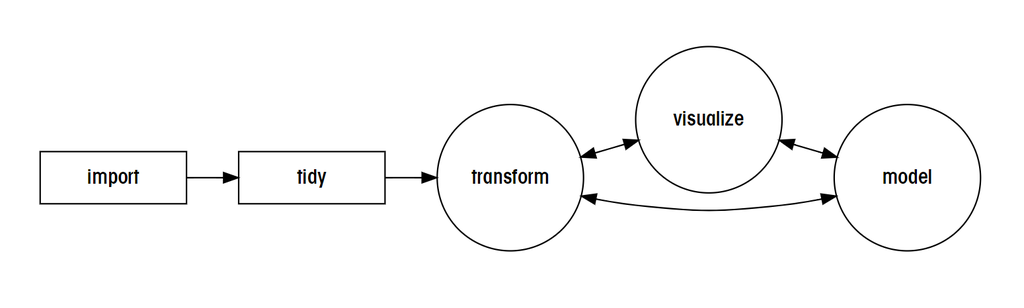

Other tidyverse packages exist, and within the same framework many more are being developed. The consistency within the tidyverse ecosystem should give you a push though, to study the other packages yourself when of interest.

Base R still is a proper alternative to the tidyverse ecosystem, so be aware that others may do things differently.